# FIFA Player position classification and market value estimation

Giovanni Dal Mas

# Player position classification and market value estimation

## 1. Abstract and motivation

FIFA is one of the most known videogames and the most famous sport title in the industry, in particular we considered FIFA 22 edition.

Each player covers a specific position on the field; what we want to do in the first part of the project is building some models to classify the position of the player, based on the values of its attributes. It’s important to consider that some players may share some features with footballers playing in another position, and this may influence our task. For example, some attacking midfielders (CAM) have a good shot and pace, just like wingers (RW, LW). We will keep this into account and adjust our classification accordingly.

In the second part of our project we will perform a regression task, building some models to evaluate the market price of a football player, using Ridge and Lasso regression.

## 2. The dataset - Description & EDA

The original dataset has been extracted from https://sofifa.com/ and contains 19239 players described by 110 different features.

### 2.1 DataFrame inspection and rough slicing

We set the seed for reproducible experiments

```r
set.seed(42)
```

First we load the dataset, and check the dimension.

```r
players_full <- read.csv("players_22.csv") #full dataframe
dim(players_full) #full dataset
```

```
## [1] 19239   110
```

We have more or less 20k players with 110 attributes. Below we look at how those attributes are named.

```r
colnames(players_full)
```

```
##   [1] "sofifa_id"                   "player_url"
##   [3] "short_name"                  "long_name"
##   [5] "player_positions"            "overall"
##   [7] "potential"                   "value_eur"
##   [9] "wage_eur"                    "age"
##  [11] "dob"                         "height_cm"
##  [13] "weight_kg"                   "club_team_id"
##  [15] "club_name"                   "league_name"
##  [17] "league_level"                "club_position"
##  [19] "club_jersey_number"          "club_loaned_from"
##  [21] "club_joined"                 "club_contract_valid_until"
##  [23] "nationality_id"              "nationality_name"
##  [25] "nation_team_id"              "nation_position"
##  [27] "nation_jersey_number"        "preferred_foot"
##  [29] "weak_foot"                   "skill_moves"
```

[output cut: 40 more lines]

To get a better general idea, we also want to look at the type of data they provide

```r
head(players_full, 10)
```

|  | sofifa_id | player_url | short_name | long_name | player_positions | overall | potential | value_eur | wage_eur | age | dob | height_cm | weight_kg | club_team_id | club_name | league_name | league_level | club_position | club_jersey_number | club_loaned_from | club_joined | club_contract_valid_until | nationality_id | nationality_name | nation_team_id | nation_position | nation_jersey_number | preferred_foot | weak_foot | … |
| --- | --- | --- | --- | --- | --- | --- | --- | --- | --- | --- | --- | --- | --- | --- | --- | --- | --- | --- | --- | --- | --- | --- | --- | --- | --- | --- | --- | --- | --- | --- |
| 1 | 158023 | https://sofifa.com/player/158023/lionel-messi/220002 | L. Messi | Lionel Andrés Messi Cuccittini | RW, ST, CF | 93 | 93 | 78000000 | 320000 | 34 | 1987-06-24 | 170 | 72 | 73 | Paris Saint-Germain | French Ligue 1 | 1 | RW | 30 |  | 2021-08-10 | 2023 | 52 | Argentina | 1369 | RW | 10 | Left | 4 | … |
| 2 | 188545 | https://sofifa.com/player/188545/robert-lewandowski/220002 | R. Lewandowski | Robert Lewandowski | ST | 92 | 92 | 119500000 | 270000 | 32 | 1988-08-21 | 185 | 81 | 21 | FC Bayern München | German 1. Bundesliga | 1 | ST | 9 |  | 2014-07-01 | 2023 | 37 | Poland | 1353 | RS | 9 | Right | 4 | … |
| 3 | 20801 | https://sofifa.com/player/20801/c-ronaldo-dos-santos-aveiro/220002 | Cristiano Ronaldo | Cristiano Ronaldo dos Santos Aveiro | ST, LW | 91 | 91 | 45000000 | 270000 | 36 | 1985-02-05 | 187 | 83 | 11 | Manchester United | English Premier League | 1 | ST | 7 |  | 2021-08-27 | 2023 | 38 | Portugal | 1354 | ST | 7 | Right | 4 | … |
| 4 | 190871 | https://sofifa.com/player/190871/neymar-da-silva-santos-jr/220002 | Neymar Jr | Neymar da Silva Santos Júnior | LW, CAM | 91 | 91 | 129000000 | 270000 | 29 | 1992-02-05 | 175 | 68 | 73 | Paris Saint-Germain | French Ligue 1 | 1 | LW | 10 |  | 2017-08-03 | 2025 | 54 | Brazil | NA |  | NA | Right | 5 | … |
| 5 | 192985 | https://sofifa.com/player/192985/kevin-de-bruyne/220002 | K. De Bruyne | Kevin De Bruyne | CM, CAM | 91 | 91 | 125500000 | 350000 | 30 | 1991-06-28 | 181 | 70 | 10 | Manchester City | English Premier League | 1 | RCM | 17 |  | 2015-08-30 | 2025 | 7 | Belgium | 1325 | RCM | 7 | Right | 5 | … |
| 6 | 200389 | https://sofifa.com/player/200389/jan-oblak/220002 | J. Oblak | Jan Oblak | GK | 91 | 93 | 112000000 | 130000 | 28 | 1993-01-07 | 188 | 87 | 240 | Atlético de Madrid | Spain Primera Division | 1 | GK | 13 |  | 2014-07-16 | 2023 | 44 | Slovenia | NA |  | NA | Right | 3 | … |
| 7 | 231747 | https://sofifa.com/player/231747/kylian-mbappe/220002 | K. Mbappé | Kylian Mbappé Lottin | ST, LW | 91 | 95 | 194000000 | 230000 | 22 | 1998-12-20 | 182 | 73 | 73 | Paris Saint-Germain | French Ligue 1 | 1 | ST | 7 |  | 2018-07-01 | 2022 | 18 | France | 1335 | LW | 10 | Right | 4 | … |
| 8 | 167495 | https://sofifa.com/player/167495/manuel-neuer/220002 | M. Neuer | Manuel Peter Neuer | GK | 90 | 90 | 13500000 | 86000 | 35 | 1986-03-27 | 193 | 93 | 21 | FC Bayern München | German 1. Bundesliga | 1 | GK | 1 |  | 2011-07-01 | 2023 | 21 | Germany | 1337 | GK | 1 | Right | 4 | … |
| 9 | 192448 | https://sofifa.com/player/192448/marc-andre-ter-stegen/220002 | M. ter Stegen | Marc-André ter Stegen | GK | 90 | 92 | 99000000 | 250000 | 29 | 1992-04-30 | 187 | 85 | 241 | FC Barcelona | Spain Primera Division | 1 | GK | 1 |  | 2014-07-01 | 2025 | 21 | Germany | NA |  | NA | Right | 4 | … |
| 10 | 202126 | https://sofifa.com/player/202126/harry-kane/220002 | H. Kane | Harry Kane | ST | 90 | 90 | 129500000 | 240000 | 27 | 1993-07-28 | 188 | 89 | 18 | Tottenham Hotspur | English Premier League | 1 | ST | 10 |  | 2010-07-28 | 2024 | 14 | England | 1318 | ST | 9 | Right | 5 | … |

We perform a rough removal of all the features that will obviously not be relevant to our classification, or some of the ones that are a obvious linear composition of other features. Moreover, our training will be performed on the league 1 players. Then, we check the dimensions again.

```r
players_full <- players_full[players_full$league_level == 1,]

players_22 <- subset(players_full, select = c("short_name","player_positions","age","potential", "international_reputation", "value_eur", "height_cm","weight_kg","pace","shooting","passing","preferred_foot","weak_foot","dribbling","defending","physic","attacking_crossing","attacking_finishing","attacking_heading_accuracy","attacking_short_passing","attacking_volleys","skill_dribbling","skill_curve","skill_fk_accuracy","skill_long_passing","skill_ball_control","movement_acceleration","movement_sprint_speed","movement_agility","movement_reactions","movement_balance","power_shot_power","power_jumping","power_stamina","power_strength","power_long_shots","mentality_aggression","mentality_interceptions","mentality_positioning","mentality_vision","mentality_penalties","mentality_composure","defending_marking_awareness","defending_standing_tackle","defending_sliding_tackle"))



dim(players_22)
```

```
## [1] 14918    45
```

Apparently we kept only 45 features. Good enough. We will remove more later by performing feature selection so stay tuned.

We have a short look at the numerical summary of all the features we selected. On a first glance they look like they need some normalization. But before that, we would love to make some visual presentations.

```r
summary(players_22)
```

```
##   short_name        player_positions        age          potential
##  Length:14918       Length:14918       Min.   :16.00   Min.   :49.00
##  Class :character   Class :character   1st Qu.:21.00   1st Qu.:67.00
##  Mode  :character   Mode  :character   Median :25.00   Median :71.00
##                                        Mean   :25.34   Mean   :71.36
##                                        3rd Qu.:29.00   3rd Qu.:76.00
##                                        Max.   :54.00   Max.   :95.00
##                                        NA's   :61      NA's   :61
##  international_reputation   value_eur           height_cm     weight_kg
##  Min.   :1.000            Min.   :     9000   Min.   :155   Min.   : 49.00
##  1st Qu.:1.000            1st Qu.:   475000   1st Qu.:176   1st Qu.: 70.00
##  Median :1.000            Median :  1000000   Median :181   Median : 75.00
##  Mean   :1.116            Mean   :  3341258   Mean   :181   Mean   : 74.84
##  3rd Qu.:1.000            3rd Qu.:  2400000   3rd Qu.:186   3rd Qu.: 80.00
##  Max.   :5.000            Max.   :194000000   Max.   :203   Max.   :107.00
##  NA's   :61               NA's   :71          NA's   :61    NA's   :61
##       pace          shooting       passing      preferred_foot
##  Min.   :28.00   Min.   :18.0   Min.   :25.00   Length:14918
##  1st Qu.:62.00   1st Qu.:42.0   1st Qu.:51.00   Class :character
##  Median :69.00   Median :55.0   Median :58.00   Mode  :character
##  Mean   :68.33   Mean   :52.8   Mean   :57.88
##  3rd Qu.:76.00   3rd Qu.:64.0   3rd Qu.:65.00
##  Max.   :97.00   Max.   :94.0   Max.   :93.00
##  NA's   :1725    NA's   :1725   NA's   :1725
##    weak_foot       dribbling       defending         physic
##  Min.   :1.000   Min.   :27.00   Min.   :15.00   Min.   :29.00
##  1st Qu.:3.000   1st Qu.:57.00   1st Qu.:38.00   1st Qu.:59.00
##  Median :3.000   Median :64.00   Median :56.00   Median :66.00
##  Mean   :2.948   Mean   :62.99   Mean   :52.03   Mean   :64.89
##  3rd Qu.:3.000   3rd Qu.:70.00   3rd Qu.:65.00   3rd Qu.:72.00
##  Max.   :5.000   Max.   :95.00   Max.   :91.00   Max.   :90.00
##  NA's   :61      NA's   :1725    NA's   :1725    NA's   :1725
##  attacking_crossing attacking_finishing attacking_heading_accuracy
##  Min.   : 6         Min.   : 2.0        Min.   : 5.00
##  1st Qu.:39         1st Qu.:31.0        1st Qu.:44.00
##  Median :54         Median :50.0        Median :55.00
##  Mean   :50         Mean   :46.2        Mean   :51.95
##  3rd Qu.:64         3rd Qu.:62.0        3rd Qu.:64.00
##  Max.   :94         Max.   :95.0        Max.   :93.00
##  NA's   :61         NA's   :61          NA's   :61
```

[output cut: 41 more lines]

```
##  Min.   : 2.00         Min.   :10.00    Min.   : 7.00       Min.   :12.0
##  1st Qu.:40.00         1st Qu.:45.00    1st Qu.:38.00       1st Qu.:50.0
##  Median :56.00         Median :56.00    Median :49.00       Median :59.0
##  Mean   :50.76         Mean   :54.49    Mean   :48.11       Mean   :58.4
##  3rd Qu.:65.00         3rd Qu.:65.00    3rd Qu.:60.00       3rd Qu.:67.0
##  Max.   :96.00         Max.   :95.00    Max.   :93.00       Max.   :96.0
##  NA's   :61            NA's   :61       NA's   :61          NA's   :61
##  defending_marking_awareness defending_standing_tackle defending_sliding_tackle
##  Min.   : 4.00               Min.   : 5.00             Min.   : 5.00
##  1st Qu.:29.00               1st Qu.:28.00             1st Qu.:26.00
##  Median :52.00               Median :55.00             Median :53.00
##  Mean   :46.86               Mean   :48.28             Mean   :46.12
##  3rd Qu.:64.00               3rd Qu.:66.00             3rd Qu.:64.00
##  Max.   :93.00               Max.   :93.00             Max.   :92.00
##  NA's   :61                  NA's   :61                NA's   :61
```

### 2.2 Managing empty entries

We look at how many NAs we have on each attribute, in order to decide if we prefer removing them or filling them.

```r
which(apply(X = players_22, MARGIN = 2, FUN = anyNA) == TRUE) # check for NA
```

```
##                  short_name            player_positions
##                           1                           2
##                         age                   potential
##                           3                           4
##    international_reputation                   value_eur
##                           5                           6
##                   height_cm                   weight_kg
##                           7                           8
##                        pace                    shooting
##                           9                          10
##                     passing              preferred_foot
##                          11                          12
##                   weak_foot                   dribbling
##                          13                          14
##                   defending                      physic
##                          15                          16
##          attacking_crossing         attacking_finishing
##                          17                          18
##  attacking_heading_accuracy     attacking_short_passing
##                          19                          20
##           attacking_volleys             skill_dribbling
##                          21                          22
##                 skill_curve           skill_fk_accuracy
##                          23                          24
##          skill_long_passing          skill_ball_control
##                          25                          26
##       movement_acceleration       movement_sprint_speed
##                          27                          28
##            movement_agility          movement_reactions
##                          29                          30
##            movement_balance            power_shot_power
##                          31                          32
##               power_jumping               power_stamina
##                          33                          34
##              power_strength            power_long_shots
##                          35                          36
##        mentality_aggression     mentality_interceptions
##                          37                          38
##       mentality_positioning            mentality_vision
##                          39                          40
##         mentality_penalties         mentality_composure
##                          41                          42
## defending_marking_awareness   defending_standing_tackle
##                          43                          44
##    defending_sliding_tackle
##                          45
```

We decide that we have a statistically dispensable number of NAs so we remove them.

```r
players <- na.omit(players_22) # delete NA
dim(players)
```

```
## [1] 13183    45
```

We still have a good chunk of the dataset left. Since goalkeepers have special stats, we also would like to take them out. Given the fact that they are not movement players they may be missing one or more attributes typical of a footballer that plays outside, such shot precision, dribbling or finishing, for this reason they may have already been discarded in the previous phase. Just to be sure, let’s verify.

```r
goalkeepers <- str_count(players$player_positions, "GK")
sum(goalkeepers)
```

```
## [1] 0
```

Indeed, there are no goalkeeper left. Thus, while they are indisposable on the field, we could not say the same about their data, as it would reduce the accuracy of the classification of the other main positions.

### 2.3 Subset creation

We create two subsets: one with the market value in euro of the player, that we will use for the regression on the market price (we will call this subset ‘players_regress’) and a second subset that does not contain such attribute, since it is not useful for the position classification that we will perform with that.

```r
#subset WITH market value (for later)

players_copy <- as.data.frame(copy(players))

players_regress <-subset(players_copy, player_positions!="GK")

#subset WITHOUT market value
players_class <-subset(players_copy, player_positions!="GK", select = -value_eur)
```

### 2.4 Labelling

Some players play in multiple positions, but we only want to identify their main one, so we only keep that one. Moreover, we turn the binary “preferred_foot” feature into a numerical type.

```r
#Keep only the main preferred position
players_class$player_positions<- word(players_class$player_positions, 1, sep = fixed(","))
unique(players_class$player_positions)
```

```
##  [1] "RW"  "ST"  "LW"  "CM"  "CDM" "CF"  "LM"  "CB"  "CAM" "LB"  "RB"  "RM"
## [13] "LWB" "RWB"
```

```r
# Left foot is -1 and Right foot is 1. Basically one-hot encoding but we only have 2 categories so its easy

players_class$preferred_foot[players_class[,"preferred_foot"]== "Left"] <- as.numeric(-1)
players_class$preferred_foot[players_class[,"preferred_foot"]== "Right"] <- as.numeric(1)
players_class$preferred_foot <- as.numeric(players_class$preferred_foot)
```

We can see some of the positions available on the game. Goalkeeper excluded, there are 26 positions, namely:

1. LWB = Left Wing Back
2. LB = Left Back
3. LCB = Left Center Back
4. CB = Center Back
5. RCB = Right Center Back
6. RB = Right Back
7. RWB = Right Wing Back
8. LDM = Left Defensive Midfield
9. CDM = Center Defensive Midfield
10. RDM = Right Defensive Midfield
11. RCM = Right Center Midfield
12. CM = Center Midfield
13. LCM = Left Center Midfield
14. RAM = Right Attacking Midfield
15. CAM = Center Attacking Midfield
16. LAM = Left Attacking Midfield
17. LM = Left Midfield
18. RM = Right Midfield
19. LW = Left Winger
20. RW = Right Winger
21. LF = Left Forward
22. CF = Center Forward
23. RF = Right Striker
24. LS = Left Striker
25. ST = Striker
26. RS = Right Striker

Since 26 labels positions are clearly too many, we cluster them into nine classes of positions based on the area of action on the field.

*Note:* Here we apply our “domain knowledge”.

Below a picture where we can visually see how we are going to group the various positions to obtain the nine classes desired.

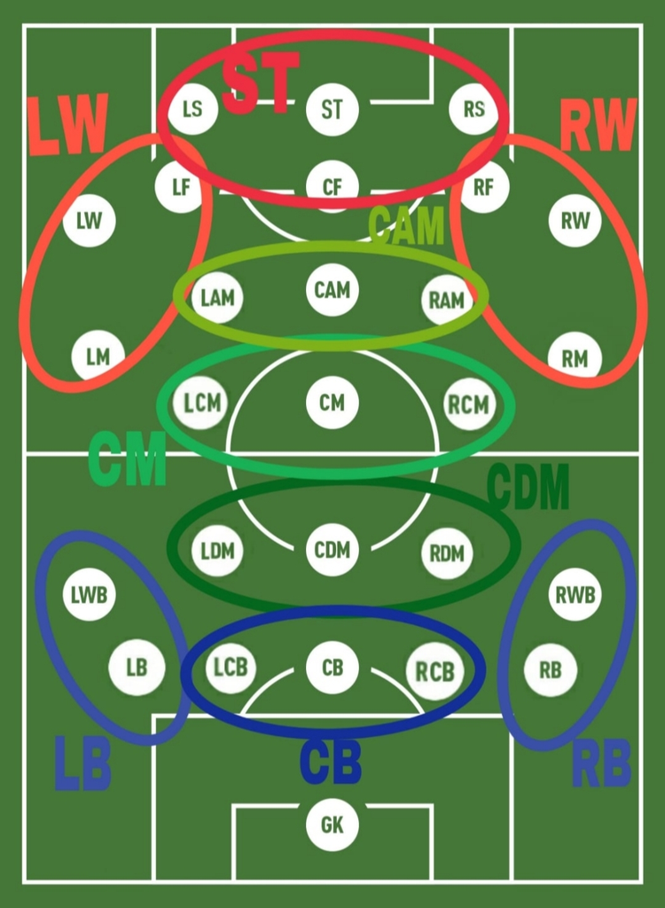

field positions

```r
#central back
players_class$player_positions[players_class[,"player_positions"]== "LCB"|players_class[,"player_positions"]== "CB"|players_class[,"player_positions"]== "RCB"] <- "CB"

#left back
players_class$player_positions[players_class[,"player_positions"]== "LWB"|players_class[,"player_positions"]== "LB"]<-"LB"

#right back
players_class$player_positions[players_class[,"player_positions"]== "RWB"|players_class[,"player_positions"]== "RB"]<-"RB"

#central deffensive midfielder
players_class$player_positions[players_class[,"player_positions"]== "LDM"|players_class[,"player_positions"]== "CDM"|players_class[,"player_positions"]== "RDM"] <- "CDM"

#central midfielder
players_class$player_positions[players_class[,"player_positions"]== "LCM"|players_class[,"player_positions"]== "CM"|players_class[,"player_positions"]== "RCM"] <- "CM"

#central attacking midfielder
players_class$player_positions[players_class[,"player_positions"]== "LAM"|players_class[,"player_positions"]== "CAM"|players_class[,"player_positions"]== "RAM"] <- "CAM"

#left winger
players_class$player_positions[players_class[,"player_positions"]== "LM"|players_class[,"player_positions"]== "LW"|players_class[,"player_positions"]== "LF"] <- "LW"

#right winger
players_class$player_positions[players_class[,"player_positions"]== "RM"|players_class[,"player_positions"]== "RW"|players_class[,"player_positions"]== "RF"] <- "RW"

#striker
players_class$player_positions[players_class[,"player_positions"]== "LS"|players_class[,"player_positions"]== "CF"|players_class[,"player_positions"]== "RS"] <- "ST"
```

Lets take a look at the distribution of our labels.

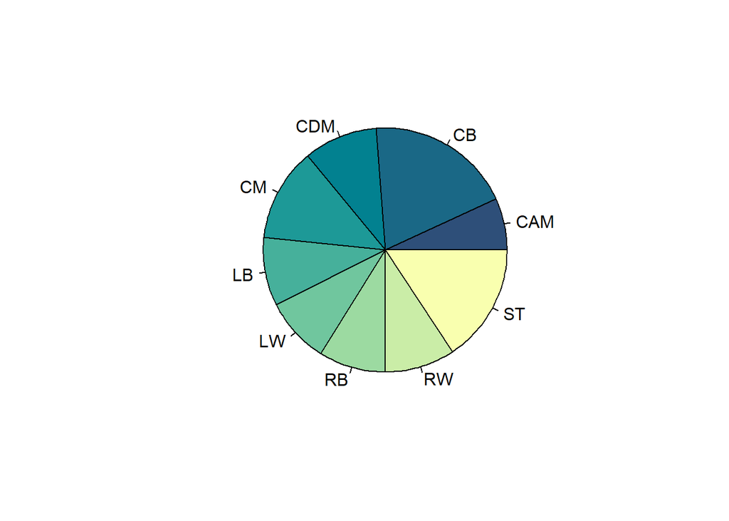

```r
cat<- table(factor(players_class$player_positions))
pie(cat,
    col = hcl.colors(length(cat), "BluYl"))
```

Time to normalize the numerical values, as promised. For that, we implement a simple re-scaling function, and we apply it on the whole dataframe.

```r
# normalization function
normalize <-function(x) { (x -min(x))/(max(x)-min(x))   }

# normalize
players_norm <- as.data.frame(lapply(players_class[, c(3:42)], normalize))
head(players_norm,5)
```

|  | age | potential | international_reputation | height_cm | weight_kg | pace | shooting | passing | preferred_foot | weak_foot | dribbling | defending | physic | attacking_crossing | attacking_finishing | attacking_heading_accuracy | attacking_short_passing | attacking_volleys | skill_dribbling | skill_curve | skill_fk_accuracy | skill_long_passing | skill_ball_control | movement_acceleration | movement_sprint_speed | movement_agility | movement_reactions | movement_balance | power_shot_power | … |
| --- | --- | --- | --- | --- | --- | --- | --- | --- | --- | --- | --- | --- | --- | --- | --- | --- | --- | --- | --- | --- | --- | --- | --- | --- | --- | --- | --- | --- | --- | --- |
| 1 | 0.7826087 | 0.9565217 | 1.00 | 0.3125000 | 0.4423077 | 0.8260870 | 0.9736842 | 0.9705882 | 0 | 0.75 | 1.0000000 | 0.2500000 | 0.5901639 | 0.8860759 | 1.0000000 | 0.6973684 | 0.9577465 | 0.9750 | 1.0000000 | 0.9878049 | 1.0000000 | 0.9726027 | 1.0000000 | 0.9142857 | 0.7571429 | 0.9275362 | 1.0000000 | 0.9857143 | 0.8800000 | … |
| 2 | 0.6956522 | 0.9347826 | 1.00 | 0.6250000 | 0.6153846 | 0.7246377 | 0.9736842 | 0.7941176 | 1 | 0.75 | 0.8676471 | 0.3815789 | 0.8688525 | 0.7088608 | 1.0000000 | 0.9605263 | 0.8732394 | 0.9875 | 0.8589744 | 0.8170732 | 0.8928571 | 0.6849315 | 0.8888889 | 0.7142857 | 0.7428571 | 0.7246377 | 0.9846154 | 0.8000000 | 0.9333333 | … |
| 3 | 0.8695652 | 0.9130435 | 1.00 | 0.6666667 | 0.6538462 | 0.8550725 | 1.0000000 | 0.8088235 | 1 | 0.75 | 0.8970588 | 0.2500000 | 0.7540984 | 0.9113924 | 1.0000000 | 0.9605263 | 0.8028169 | 0.9500 | 0.8974359 | 0.8414634 | 0.8809524 | 0.7808219 | 0.8888889 | 0.8285714 | 0.8714286 | 0.8550725 | 1.0000000 | 0.6857143 | 0.9866667 | … |
| 4 | 0.5652174 | 0.9130435 | 1.00 | 0.4166667 | 0.3653846 | 0.9130435 | 0.8552632 | 0.8970588 | 1 | 1.00 | 0.9852941 | 0.2894737 | 0.5573770 | 0.8860759 | 0.8588235 | 0.6052632 | 0.8873239 | 0.9500 | 0.9871795 | 0.9268293 | 0.9166667 | 0.8356164 | 0.9861111 | 0.9428571 | 0.8857143 | 1.0000000 | 0.9230769 | 0.8285714 | 0.8000000 | … |
| 5 | 0.6086957 | 0.9130435 | 0.75 | 0.5416667 | 0.4038462 | 0.6956522 | 0.8947368 | 1.0000000 | 1 | 1.00 | 0.8970588 | 0.6447368 | 0.8032787 | 1.0000000 | 0.8470588 | 0.5000000 | 1.0000000 | 0.9000 | 0.8974359 | 0.8902439 | 0.8690476 | 1.0000000 | 0.9305556 | 0.7000000 | 0.7000000 | 0.7536232 | 0.9538462 | 0.7428571 | 0.9466667 | … |

### 2.5 Correlation matrix and feature selection

We create a correlation matrix. It is big and maybe a bit hard to read, but R gives us the visually appealing option to group plotted features into highly correlated clusters.

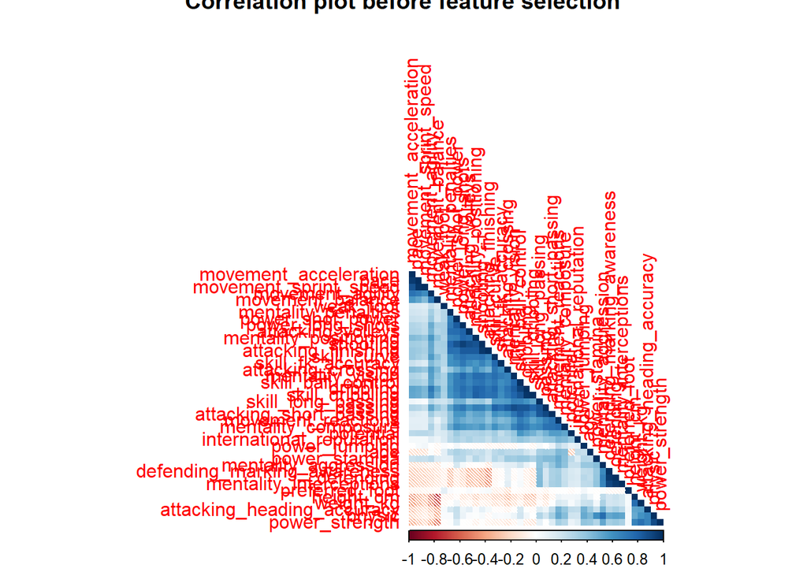

```r
cormatrix <- cor(players_norm)
corrplot(cor(players_norm), method = 'shade', sig.level = 0.10, type = 'lower', order = 'hclust', title = "Correlation plot before feature selection")
```

Now, in order to reduce the number of features, we take away the ones that provide the data with the highest overall correlation.

```r
highcorr <- findCorrelation(cormatrix, cutoff=0.8)
highcorr
```

```
##  [1] 11  8 19 23  7 36 33 15 17 24 12 13 25 35
```

```r
col2<-colnames(players_norm)
col2
```

```
##  [1] "age"                         "potential"
##  [3] "international_reputation"    "height_cm"
##  [5] "weight_kg"                   "pace"
##  [7] "shooting"                    "passing"
##  [9] "preferred_foot"              "weak_foot"
## [11] "dribbling"                   "defending"
## [13] "physic"                      "attacking_crossing"
## [15] "attacking_finishing"         "attacking_heading_accuracy"
## [17] "attacking_short_passing"     "attacking_volleys"
## [19] "skill_dribbling"             "skill_curve"
## [21] "skill_fk_accuracy"           "skill_long_passing"
## [23] "skill_ball_control"          "movement_acceleration"
## [25] "movement_sprint_speed"       "movement_agility"
## [27] "movement_reactions"          "movement_balance"
## [29] "power_shot_power"            "power_jumping"
## [31] "power_stamina"               "power_strength"
## [33] "power_long_shots"            "mentality_aggression"
## [35] "mentality_interceptions"     "mentality_positioning"
## [37] "mentality_vision"            "mentality_penalties"
## [39] "mentality_composure"         "defending_marking_awareness"
```

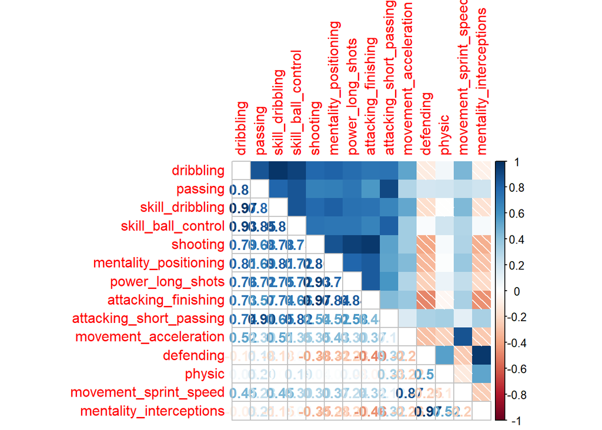

```r
col2<-col2[-highcorr]
corrplot.mixed(cor(players_norm[highcorr]), lower = "number", upper="shade", tl.pos = 'lt')
```

We take a look if we eliminated some of the dark spots from our correlation matrix.

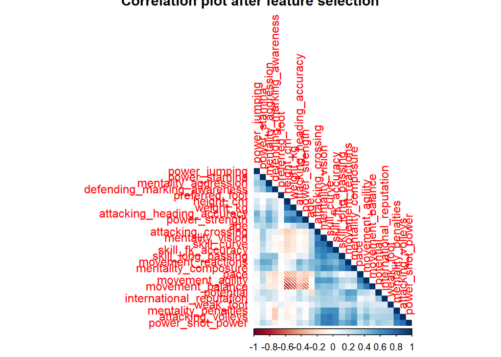

```r
corrplot(cor(players_norm[col2]), type = 'lower',method = 'shade', order = 'hclust', title = "Correlation plot after feature selection")
```

```r
players_f.selected <- players_norm[col2]  #features left
players_model <- subset(players_f.selected)

#we can add the positions back
players_model$player_positions <- c(players_class$player_positions)
```

```r
colnames(players_model)
```

```
##  [1] "age"                         "potential"
##  [3] "international_reputation"    "height_cm"
##  [5] "weight_kg"                   "pace"
##  [7] "preferred_foot"              "weak_foot"
##  [9] "attacking_crossing"          "attacking_heading_accuracy"
## [11] "attacking_volleys"           "skill_curve"
## [13] "skill_fk_accuracy"           "skill_long_passing"
## [15] "movement_agility"            "movement_reactions"
## [17] "movement_balance"            "power_shot_power"
## [19] "power_jumping"               "power_stamina"
## [21] "power_strength"              "mentality_aggression"
## [23] "mentality_vision"            "mentality_penalties"
## [25] "mentality_composure"         "defending_marking_awareness"
## [27] "player_positions"
```

We did. Looks much better and ready for further investigation.

### 2.6 Individual feature investigation

We want to look at the individual distributions of each of the features left. We fit violin plots, and put boxplots on top of them.

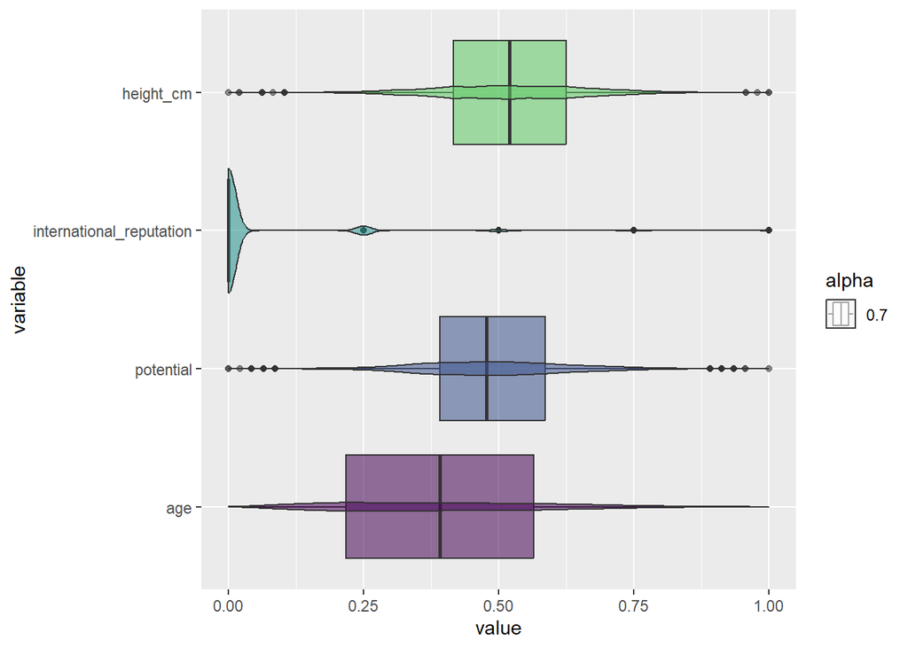

```r
# here we do the cool violin plots to check distributions

# set up the plotting layout as a 4x2 grid
par(mfrow = c(4, 2))

# create a combined boxplot and violin plot using ggplot2
ggplot(data = melt(players_f.selected[, 1:4]),  # convert data to long format (tabular form)
       aes(y = variable, x = value, fill = variable, alpha = 0.7)) +  # specify aesthetics
  geom_boxplot() +  # add boxplot layer
  geom_violin() +  # add violin plot layer
  scale_fill_manual(values = viridis(5)) +  # set fill colors using Viridis palette
  guides(fill = "none")  # remove legend for fill colors
```

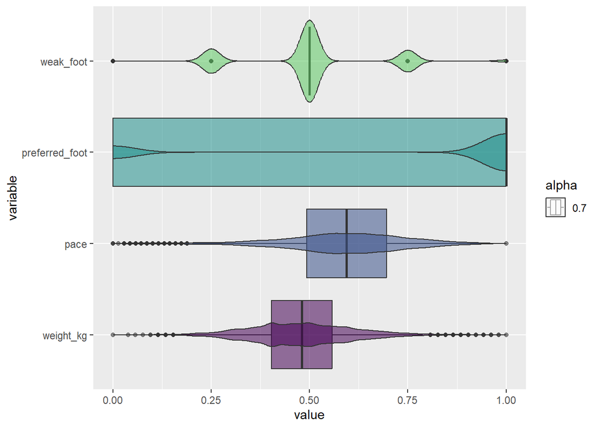

```r
ggplot(data = melt(players_f.selected[,5:8]), aes(y = variable, x = value, fill = variable, alpha = 0.7)) + geom_boxplot() + geom_violin() + scale_fill_manual(values = viridis(5)) + guides(fill = "none")
```

Weak foot is a discrete RV with values in 1-5. Preferred foot is +/-1, as discussed above. Still, as in real life, a significantly larger proportion of right-footed people.

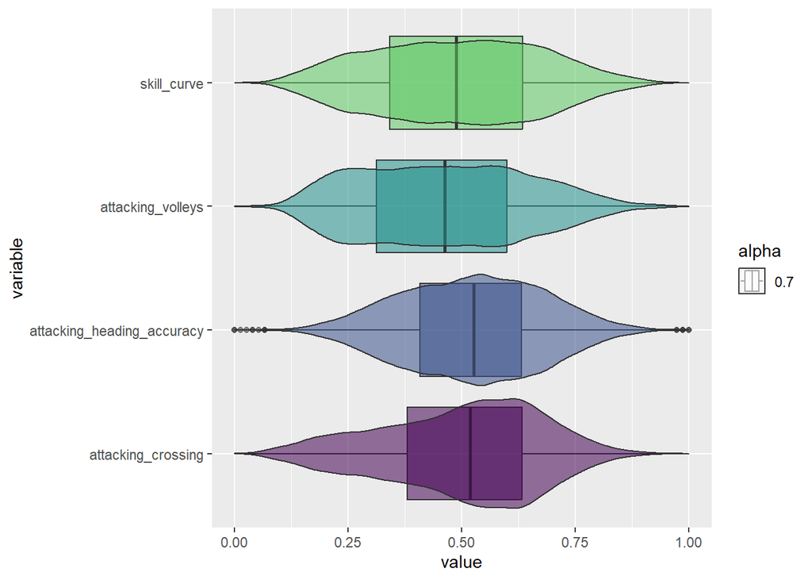

```r
ggplot(data = melt(players_f.selected[,9:12]), aes(y = variable, x = value, fill = variable, alpha = 0.7)) + geom_boxplot() + geom_violin() + scale_fill_manual(values = viridis(5)) + guides(fill = "none")
```

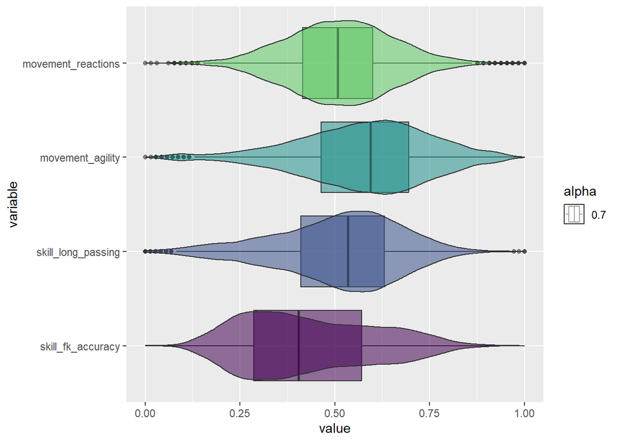

```r
ggplot(data = melt(players_f.selected[,13:16]), aes(y = variable, x = value, fill = variable, alpha = 0.7)) + geom_boxplot() + geom_violin() + scale_fill_manual(values = viridis(5)) + guides(fill = "none")
```

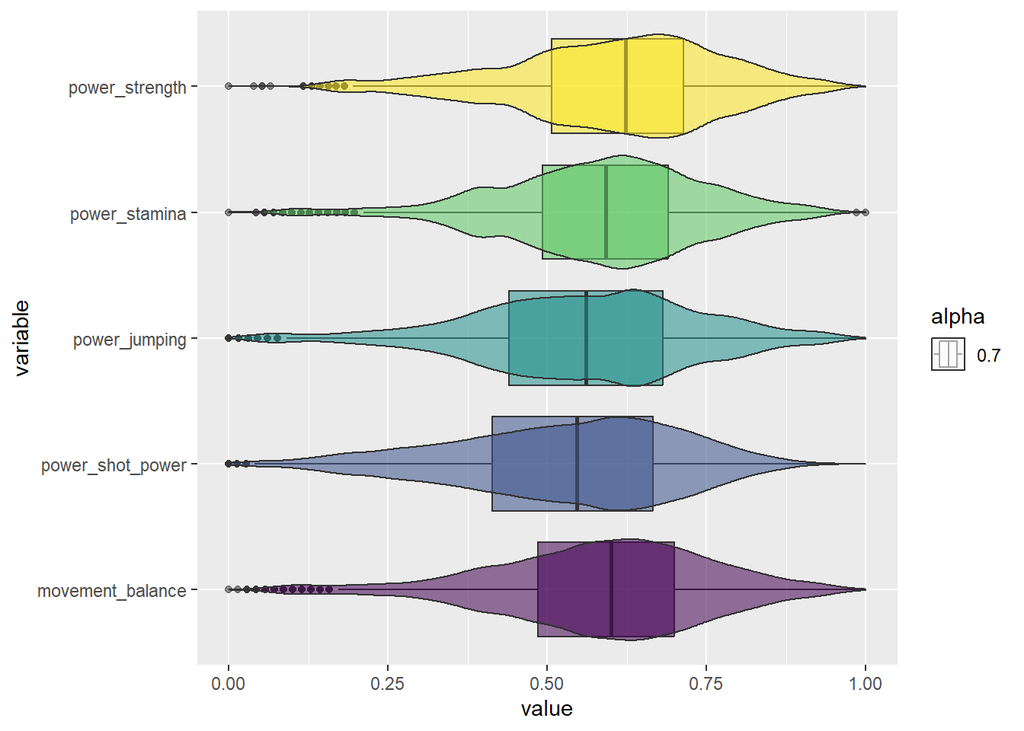

```r
ggplot(data = melt(players_f.selected[,17:21]), aes(y = variable, x = value, fill = variable, alpha = 0.7)) + geom_boxplot() + geom_violin() + scale_fill_manual(values = viridis(5)) + guides(fill = "none")
```

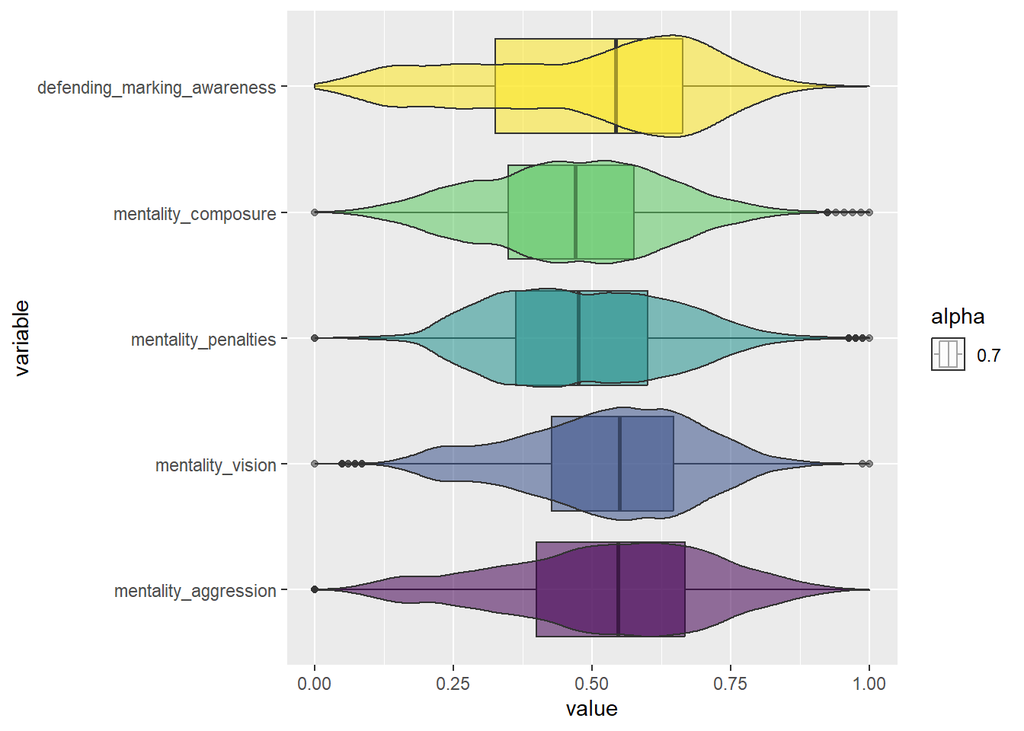

```r
ggplot(data = melt(players_f.selected[,22:26]), aes(y = variable, x = value, fill = variable, alpha = 0.7)) + geom_boxplot() + geom_violin() + scale_fill_manual(values = viridis(5)) + guides(fill = "none")
```

### 2.7 Principal Component Analysis

```r
players.pca<-prcomp(players_f.selected,center=TRUE, scale.=TRUE)
summary(players.pca)
```

```
## Importance of components:
##                           PC1    PC2     PC3     PC4     PC5     PC6     PC7
## Standard deviation     2.8232 2.2849 1.47152 1.20892 1.13086 1.04265 0.92988
## Proportion of Variance 0.3066 0.2008 0.08328 0.05621 0.04919 0.04181 0.03326
## Cumulative Proportion  0.3066 0.5074 0.59064 0.64685 0.69604 0.73785 0.77111
##                           PC8     PC9   PC10    PC11    PC12    PC13    PC14
## Standard deviation     0.8861 0.81169 0.7084 0.67291 0.63723 0.61597 0.56246
## Proportion of Variance 0.0302 0.02534 0.0193 0.01742 0.01562 0.01459 0.01217
## Cumulative Proportion  0.8013 0.82665 0.8459 0.86336 0.87898 0.89358 0.90574
##                           PC15    PC16    PC17    PC18   PC19    PC20    PC21
## Standard deviation     0.52867 0.51801 0.50465 0.48131 0.4700 0.45150 0.43178
## Proportion of Variance 0.01075 0.01032 0.00979 0.00891 0.0085 0.00784 0.00717
## Cumulative Proportion  0.91649 0.92681 0.93661 0.94552 0.9540 0.96186 0.96903
##                          PC22    PC23    PC24    PC25    PC26
## Standard deviation     0.4265 0.41564 0.40683 0.39030 0.36437
## Proportion of Variance 0.0070 0.00664 0.00637 0.00586 0.00511
## Cumulative Proportion  0.9760 0.98267 0.98903 0.99489 1.00000
```

We obtain 26 components. We want to visualize them.

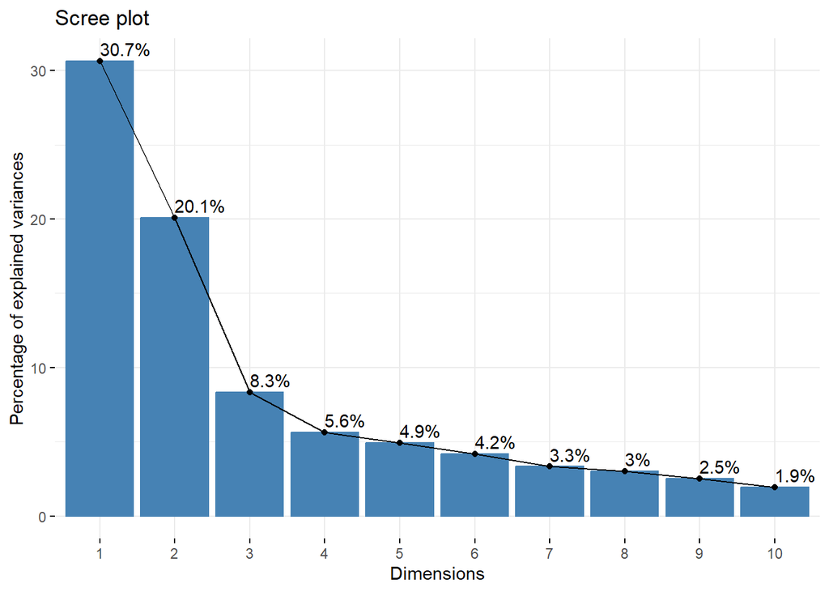

```r
fviz_eig(players.pca, addlabels = TRUE)
```

The first 5 components account for 69.6% of the explained variance, while the first 2 for 50.8% of it. Now we want to see how our features project into the main 2D factor plane.

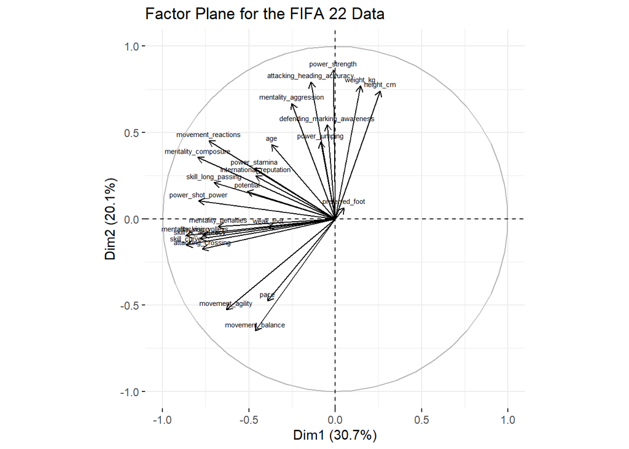

```r
fviz_pca_var(players.pca, labelsize = 2, alpha.var = 1.0, title = "Factor Plane for the FIFA 22 Data")
```

From the factor plane we can appreciate the relationship among particular attributes. Pace is positively correlated with agility and balance, which makes absolute sense since agility and a good balance are the key elements of the fastest players on the field. Another group of highly correlated features is the one that comprehends the physical attributes and aerial game: the taller and heaviest guys are usually the strongest ones and given their physical structure they are more likely to be also good headers. All these characteristics are the more desirable for a central defender (CB) and this is the reason why also aggression and marking awareness belong to the group.

## 3. Modelling - Multiclass classification

Now its finally time to dive into the actual modelling process. We experiment and compare different classification algorithms.

### 3.1 Train-validation split

Classical split for training and testing models. We keep the classical 70%-30% approach.

```r
## 70% of the sample size
smp_size <- floor(0.7 * nrow(players_model))

train_ind <- sample(seq_len(nrow(players_model)), size = smp_size)

train_with_label <- players_model[train_ind, ]
test_with_label <- players_model[-train_ind, ]

print('Train set size:')
```

```
## [1] "Train set size:"
```

```r
print(dim(train_with_label))
```

```
## [1] 9228   27
```

```r
print('Validation set size:')
```

```
## [1] "Validation set size:"
```

```r
print(dim(test_with_label))
```

```
## [1] 3955   27
```

We factorize the labels, so we can use them in our models.

```r
# factorize labels
train_y <- as.factor(train_with_label[,27])
test_y <- as.factor(test_with_label[,27])
# remove labels from sets
train <- train_with_label[1:(length(train_with_label)-1)]
test <- test_with_label[1:(length(test_with_label)-1)]
head(test)
```

|  | age | potential | international_reputation | height_cm | weight_kg | pace | preferred_foot | weak_foot | attacking_crossing | attacking_heading_accuracy | attacking_volleys | skill_curve | skill_fk_accuracy | skill_long_passing | movement_agility | movement_reactions | movement_balance | power_shot_power | power_jumping | power_stamina | power_strength | mentality_aggression | mentality_vision | mentality_penalties | mentality_composure | defending_marking_awareness |
| --- | --- | --- | --- | --- | --- | --- | --- | --- | --- | --- | --- | --- | --- | --- | --- | --- | --- | --- | --- | --- | --- | --- | --- | --- | --- | --- |
| 6 | 0.2608696 | 1.0000000 | 0.75 | 0.5625000 | 0.4615385 | 1.0000000 | 1 | 0.75 | 0.7974684 | 0.7236842 | 0.9125 | 0.8292683 | 0.7023810 | 0.6986301 | 0.9420290 | 0.9846154 | 0.8142857 | 0.8800000 | 0.7424242 | 0.8732394 | 0.7532468 | 0.5600000 | 0.8414634 | 0.8250 | 0.8787879 | 0.1927711 |
| 10 | 0.5217391 | 0.8695652 | 0.75 | 0.5833333 | 0.5576923 | 0.8695652 | 1 | 1.00 | 0.8607595 | 0.6710526 | 0.8500 | 0.8902439 | 0.7619048 | 0.7397260 | 0.8550725 | 0.9538462 | 0.7428571 | 0.9066667 | 0.4696970 | 0.8732394 | 0.5844156 | 0.5600000 | 0.8536585 | 0.7500 | 0.8939394 | 0.4819277 |
| 11 | 0.5652174 | 0.8695652 | 0.50 | 0.6250000 | 0.6730769 | 0.5362319 | 1 | 0.50 | 0.5443038 | 0.8157895 | 0.6500 | 0.6097561 | 0.7619048 | 0.8767123 | 0.4927536 | 0.8923077 | 0.5714286 | 0.9066667 | 0.8787879 | 0.8873239 | 0.9220779 | 0.9466667 | 0.8170732 | 0.6625 | 0.8181818 | 0.9036145 |
| 12 | 0.5652174 | 0.8695652 | 0.75 | 0.7916667 | 0.8269231 | 0.7246377 | 1 | 0.50 | 0.4810127 | 0.9210526 | 0.4375 | 0.5853659 | 0.7142857 | 0.9041096 | 0.4927536 | 0.8923077 | 0.3857143 | 0.8133333 | 0.9242424 | 0.6056338 | 0.9480519 | 0.8400000 | 0.6341463 | 0.6125 | 0.9090909 | 0.9879518 |
| 17 | 0.7826087 | 0.8478261 | 1.00 | 0.5625000 | 0.6538462 | 0.6376812 | 1 | 0.75 | 0.8227848 | 0.8815789 | 1.0000 | 0.9024390 | 0.8571429 | 0.7808219 | 0.6956522 | 0.9692308 | 0.7428571 | 0.9200000 | 0.6060606 | 0.7323944 | 0.8571429 | 0.8933333 | 0.8658537 | 0.8750 | 0.8636364 | 0.3855422 |
| 20 | 0.4347826 | 0.8695652 | 0.75 | 0.3125000 | 0.3846154 | 0.9130435 | 1 | 0.50 | 0.8101266 | 0.3815789 | 0.7125 | 0.8170732 | 0.7380952 | 0.6712329 | 0.9710145 | 0.9384615 | 0.9571429 | 0.7733333 | 0.4242424 | 0.7464789 | 0.5844156 | 0.5200000 | 0.8414634 | 0.6750 | 0.7272727 | 0.4457831 |

Just to take a sneak peek, this is how the validation labels are roughly distributed on the factor plane.We notice that the factor plane separates some types of labels quite good (e.g. CB), some not.

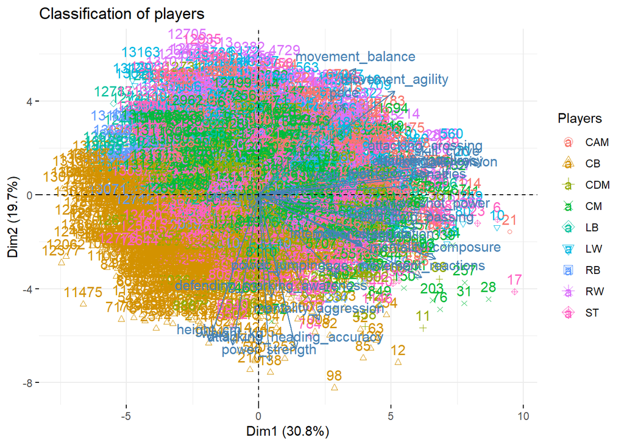

```r
test.pca<-prcomp(test,center=TRUE, scale.=TRUE)
fviz_pca_biplot(test.pca,
                label = "all",
                col.ind = test_y,
                legend.title = "Players",
                title = "Classification of players")
```

### 3.2 Useful functions

Before we train any model, we want to create a function that computes accuracy, and one that selects the missclassified data so we can visualize it later on the factor plane.

```r
accuracy <- function(x){sum(diag(x)/(sum(rowSums(x)))) * 100}

missclassified <- function(pred, label){
  l<- pred
  l[c(pred)==c(label)]<- 0
  return (as.factor(l))
}

#cross validation
ctrl <-  trainControl(method = "repeatedcv", number = 100, repeats = 10)
```

### 3.3 Knn

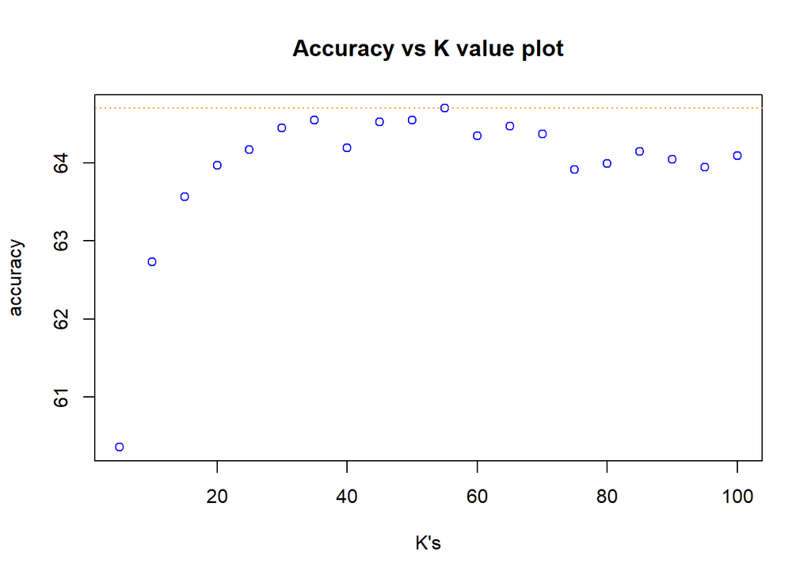

```r
##run knn function
class <- factor(c(train_y))

train <- train[1:(length(train)-1)]
test <- test[1:(length(test)-1)]

accuracy_vect <- c()
ks<- c()

for(k1 in seq(5,100,5)) {
    test_pred <-knn(train = train, test = test, cl = class, k = k1)
    accuracy_vect <- append(accuracy_vect,accuracy(table(test_y,test_pred)))
    ks <- append(ks, k1)
}

plot(ks, accuracy_vect, type = "p", col="blue", xlab="K's", ylab="accuracy", main="Accuracy vs K value plot")
abline(h = max(accuracy_vect), col = "darkorange", lty = 3)
```

We get the best k and its accuracy, represented by the orange line, namely k = 55, with 64.7% accuracy.

```r
print('The best K in our case is:')
```

```
## [1] "The best K in our case is:"
```

```r
print(ks[which.max(accuracy_vect)])
```

```
## [1] 55
```

```r
print('And it gives us an accuracy of:' )
```

```
## [1] "And it gives us an accuracy of:"
```

```r
print(accuracy_vect[which.max(accuracy_vect)])
```

```
## [1] 64.70291
```

Using the best k ( k=55) we generate a confusion matrix to check misslabeled data

```r
set.seed(42)
pred_knn <-knn(train = train, test = test, cl = class, k = 55)
```

```r
conf_mat_knn <- confusionMatrix(data=pred_knn, reference = test_y)
conf_mat_knn
```

```
## Confusion Matrix and Statistics
##
##           Reference
## Prediction CAM  CB CDM  CM  LB  LW  RB  RW  ST
##        CAM  80   0   1  38   1  22   0  25   4
##        CB    0 655  46   2   8   0  18   0   8
##        CDM   1  34 165  55   1   1  16   3   3
##        CM  101   3 149 332  14  33  29  54  23
##        LB   13  31  21  33 317  38   4  16  21
##        LW   37   0   0   4   4 114   3  81  19
##        RB    1  23   6   6  24  10 260  23   2
##        RW   40   0   0  14   6  82   4 121  23
##        ST   12   6   2   3   0  45   9  41 511
##
## Overall Statistics
##
##                Accuracy : 0.646
##                  95% CI : (0.6309, 0.6609)
##     No Information Rate : 0.1901
##     P-Value [Acc > NIR] : < 2.2e-16
##
##                   Kappa : 0.5953
##
##  Mcnemar's Test P-Value : NA
##
## Statistics by Class:
##
##                      Class: CAM Class: CB Class: CDM Class: CM Class: LB
## Sensitivity             0.28070    0.8710    0.42308   0.68172   0.84533
## Specificity             0.97520    0.9744    0.96802   0.88293   0.95056
## Pos Pred Value          0.46784    0.8887    0.59140   0.44986   0.64170
## Neg Pred Value          0.94582    0.9699    0.93879   0.95182   0.98324
## Prevalence              0.07206    0.1901    0.09861   0.12314   0.09482
## Detection Rate          0.02023    0.1656    0.04172   0.08394   0.08015
## Detection Prevalence    0.04324    0.1863    0.07054   0.18660   0.12491
## Balanced Accuracy       0.62795    0.9227    0.69555   0.78233   0.89795
##                      Class: LW Class: RB Class: RW Class: ST
## Sensitivity            0.33043   0.75802   0.33242    0.8322
## Specificity            0.95900   0.97370   0.95294    0.9647
## Pos Pred Value         0.43511   0.73239   0.41724    0.8124
## Neg Pred Value         0.93745   0.97694   0.93370    0.9690
## Prevalence             0.08723   0.08673   0.09204    0.1552
## Detection Rate         0.02882   0.06574   0.03059    0.1292
## Detection Prevalence   0.06625   0.08976   0.07332    0.1590
## Balanced Accuracy      0.64472   0.86586   0.64268    0.8985
```

### 3.4 Logistic regression

```r
set.seed(42)
modellr <- nnet::multinom( train_y~., data = train,trControl=crtl)
set.seed(42)
pred_lr <- predict(modellr, test, type = "class")
accuracy(table(test_y, pred_lr))
```

```
## [1] 69.50695
```

The logistic regression performs better, with 69.5% accuracy. Let’s have a look at the confusion matrix.

```r
conf_mat <- confusionMatrix(data=pred_lr, reference = test_y)
conf_mat
```

```
## Confusion Matrix and Statistics
##
##           Reference
## Prediction CAM  CB CDM  CM  LB  LW  RB  RW  ST
##        CAM 119   0   0  52   0  32   0  28  13
##        CB    0 671  46   4   9   0  15   0   2
##        CDM   3  24 215  61   1   1   4   5   1
##        CM   76   4 109 354   8  10   3  21   7
##        LB    4  19   4   2 307  19   4   8   3
##        LW   26   0   0   2  13  77   0  81  17
##        RB    1  28  15   6  32   9 301  25   5
##        RW   27   0   0   6   5 143  14 163  24
##        ST   29   6   1   0   0  54   2  33 542
##
## Overall Statistics
##
##                Accuracy : 0.6951
##                  95% CI : (0.6805, 0.7094)
##     No Information Rate : 0.1901
##     P-Value [Acc > NIR] : < 2.2e-16
##
##                   Kappa : 0.6517
##
##  Mcnemar's Test P-Value : NA
##
## Statistics by Class:
##
##                      Class: CAM Class: CB Class: CDM Class: CM Class: LB
## Sensitivity             0.41754    0.8923    0.55128   0.72690   0.81867
## Specificity             0.96594    0.9763    0.97195   0.93137   0.98240
## Pos Pred Value          0.48770    0.8983    0.68254   0.59797   0.82973
## Neg Pred Value          0.95527    0.9748    0.95192   0.96045   0.98103
## Prevalence              0.07206    0.1901    0.09861   0.12314   0.09482
## Detection Rate          0.03009    0.1697    0.05436   0.08951   0.07762
## Detection Prevalence    0.06169    0.1889    0.07965   0.14968   0.09355
## Balanced Accuracy       0.69174    0.9343    0.76162   0.82914   0.90053
##                      Class: LW Class: RB Class: RW Class: ST
## Sensitivity            0.22319   0.87755   0.44780    0.8827
## Specificity            0.96150   0.96650   0.93901    0.9626
## Pos Pred Value         0.35648   0.71327   0.42670    0.8126
## Neg Pred Value         0.92832   0.98811   0.94374    0.9781
## Prevalence             0.08723   0.08673   0.09204    0.1552
## Detection Rate         0.01947   0.07611   0.04121    0.1370
## Detection Prevalence   0.05461   0.10670   0.09659    0.1686
## Balanced Accuracy      0.59234   0.92203   0.69341    0.9227
```

### 3.5 Random Forrest

The hyperparameter we experiment with is ‘mtry’, that controls the number of variables randomly sampled as candidates for splitting at each tree node. Changing the number of trees does not do much, and from previous experimentation we realized that around 500 is the optimum value.

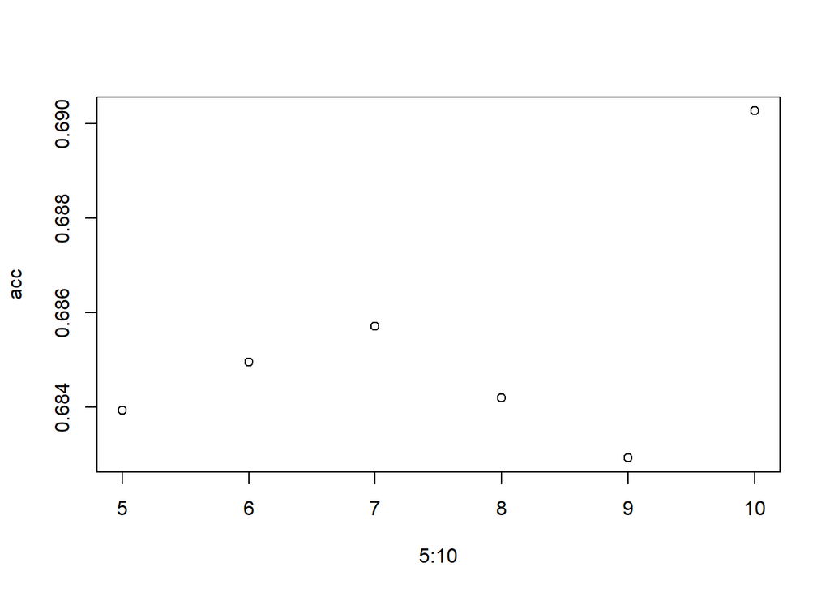

```r
acc = c()  # empty vector to store accuracy values
i = 5

# Loop through values of i from 5 to 10
for (i in seq(5,10)) {
  # Train a random forest model with varying mtry values
  model_RF <- randomForest(train_y ~ ., data = train, ntree = 500, mtry = i, importance = TRUE)

  # Make predictions using the trained random forest model
  prediction_RF <- predict(model_RF, test, type = "class")

  # Calculate accuracy and store it in the 'acc' vector
  acc[i - 4] = mean(prediction_RF == test_y)  # Accuracy is calculated by comparing predicted and actual classes
}

# Plot accuracy values against the mtry values
plot(5:10, acc)
```

```r
acc
```

```
## [1] 0.6839444 0.6849558 0.6857143 0.6841972 0.6829330 0.6902655
```

```r
model_rf <- randomForest(train_y ~ ., data = train, ntree = 500, mtry = 9, importance = TRUE)
pred_rf <- predict(model_rf, test, type = "class")
```

```r
conf_mat <- confusionMatrix(data=pred_rf, reference = test_y)
conf_mat
```

```
## Confusion Matrix and Statistics
##
##           Reference
## Prediction CAM  CB CDM  CM  LB  LW  RB  RW  ST
##        CAM 103   0   2  43   0  21   0  23  10
##        CB    1 687  57   3  11   0  22   0   3
##        CDM   1  25 182  68   1   1   7   4   1
##        CM   88   3 130 339  13  14  10  32   9
##        LB    3  16   6   7 304  21   4  12   3
##        LW   39   0   0   7   9 114   4  96  17
##        RB    3  17  12   4  30  15 281  30   2
##        RW   24   0   0   8   6 109  10 133  26
##        ST   23   4   1   8   1  50   5  34 543
##
## Overall Statistics
##
##                Accuracy : 0.6791
##                  95% CI : (0.6643, 0.6937)
##     No Information Rate : 0.1901
##     P-Value [Acc > NIR] : < 2.2e-16
##
##                   Kappa : 0.6329
##
##  Mcnemar's Test P-Value : NA
##
## Statistics by Class:
##
##                      Class: CAM Class: CB Class: CDM Class: CM Class: LB
## Sensitivity             0.36140    0.9136    0.46667   0.69610   0.81067
## Specificity             0.97302    0.9697    0.96971   0.91378   0.97989
## Pos Pred Value          0.50990    0.8763    0.62759   0.53135   0.80851
## Neg Pred Value          0.95151    0.9795    0.94325   0.95538   0.98016
## Prevalence              0.07206    0.1901    0.09861   0.12314   0.09482
## Detection Rate          0.02604    0.1737    0.04602   0.08571   0.07686
## Detection Prevalence    0.05107    0.1982    0.07332   0.16131   0.09507
## Balanced Accuracy       0.66721    0.9416    0.71819   0.80494   0.89528
##                      Class: LW Class: RB Class: RW Class: ST
## Sensitivity            0.33043   0.81924   0.36538    0.8844
## Specificity            0.95235   0.96872   0.94904    0.9623
## Pos Pred Value         0.39860   0.71320   0.42089    0.8117
## Neg Pred Value         0.93704   0.98259   0.93652    0.9784
## Prevalence             0.08723   0.08673   0.09204    0.1552
## Detection Rate         0.02882   0.07105   0.03363    0.1373
## Detection Prevalence   0.07231   0.09962   0.07990    0.1692
## Balanced Accuracy      0.64139   0.89398   0.65721    0.9233
```

### 3.6 SVM

```r
svm1 <- svm(formula= train_y~., data=train,
          type="C-classification", kernal="radial",
          gamma=0.1, cost=10)
```

```r
pred_svm <- predict(svm1,test, type = "class")
accuracy(table(test_y, pred_svm))
```

```
## [1] 67.10493
```

We produce a summary of the model.

```r
summary(svm1)
```

```
##
## Call:
## svm(formula = train_y ~ ., data = train, type = "C-classification",
##     kernal = "radial", gamma = 0.1, cost = 10)
##
##
## Parameters:
##    SVM-Type:  C-classification
##  SVM-Kernel:  radial
##        cost:  10
##
## Number of Support Vectors:  7006
##
##  ( 793 875 566 837 611 639 829 1058 798 )
##
##
## Number of Classes:  9
##
## Levels:
##  CAM CB CDM CM LB LW RB RW ST
```

```r
conf_mat <- confusionMatrix(data=pred_svm, reference = test_y)
conf_mat
```

```
## Confusion Matrix and Statistics
##
##           Reference
## Prediction CAM  CB CDM  CM  LB  LW  RB  RW  ST
##        CAM 102   0  10  54   1  21   0  34  14
##        CB    1 676  43   5  12   0  23   0   1
##        CDM   5  25 207  58   0   1  12   3   2
##        CM   63   7  96 317   8  11   5  21   8
##        LB    2  20   7   4 296  19  15   7   5
##        LW   47   0   3  17  18 134   7 110  26
##        RB    0  20  17   9  25   9 263  17   6
##        RW   40   0   3  15  13 108  15 139  32
##        ST   25   4   4   8   2  42   3  33 520
##
## Overall Statistics
##
##                Accuracy : 0.671
##                  95% CI : (0.6562, 0.6857)
##     No Information Rate : 0.1901
##     P-Value [Acc > NIR] : < 2.2e-16
##
##                   Kappa : 0.6245
##
##  Mcnemar's Test P-Value : NA
##
## Statistics by Class:
##
##                      Class: CAM Class: CB Class: CDM Class: CM Class: LB
## Sensitivity             0.35789    0.8989    0.53077   0.65092   0.78933
## Specificity             0.96349    0.9735    0.97027   0.93685   0.97793
## Pos Pred Value          0.43220    0.8883    0.66134   0.59142   0.78933
## Neg Pred Value          0.95079    0.9762    0.94975   0.95028   0.97793
## Prevalence              0.07206    0.1901    0.09861   0.12314   0.09482
## Detection Rate          0.02579    0.1709    0.05234   0.08015   0.07484
## Detection Prevalence    0.05967    0.1924    0.07914   0.13552   0.09482
## Balanced Accuracy       0.66069    0.9362    0.75052   0.79389   0.88363
##                      Class: LW Class: RB Class: RW Class: ST
## Sensitivity            0.38841   0.76676   0.38187    0.8469
## Specificity            0.93684   0.97148   0.93706    0.9638
## Pos Pred Value         0.37017   0.71858   0.38082    0.8112
## Neg Pred Value         0.94127   0.97771   0.93733    0.9716
## Prevalence             0.08723   0.08673   0.09204    0.1552
## Detection Rate         0.03388   0.06650   0.03515    0.1315
## Detection Prevalence   0.09153   0.09254   0.09229    0.1621
## Balanced Accuracy      0.66262   0.86912   0.65947    0.9053
```

### 3.7 Label Grouping

The accuracies obtained are decent but not great, and the confusion matrix clearly explains why. Positions like CB, ST, LB, RB get classified really well. On the opposite side, positions like CAM/CM and RW/LW get often confused.

The first missclassification is explainable with basic attributes of the role. Centrer Attacking Midfielder (CAM) shares a lot of attacking characteristics with the Winger such as shooting and pace but also many with CM, like passing. This common attributes of course hindrance the task of the machine learning model.

It is a bit more tricky to detect why Left Winger and Right Winger get missclassified, when other positions that depends on the side (left or right), such Left Back and Right Back, are easily distinguished. For LB and RB the preferred foot plays a big role, since it’s hard to find a righty who plays on the left and viceversa, because they cross and tackle mostly with their dominant foot. For RW and LW the distinction is less definable based on the preferred foot. On one hand, a lot of righty players like to play as Left Winger so they can converge to the center to shoot with their strong foot. Same is true for lefty on RW. On the other hand, many Wingers like to cross more, so they tend to do it with their preferred foot (LW with the left foot and RW with the right one). So for the model of course it’s really not an easy job to detect these differences that pertain to the single player style of play; and this problem explains the drop in accuracy for these positions. In order to improve the accuracy of our classifiers, we group RW and LW together in a new position ‘W = Winger’ and we also group the CAM with CM in the class “CM = Center Midfielder”.

```r
test_y2 <- test_y
levels(test_y2)[levels(test_y2) == "RW"| levels(test_y2) == "LW"] <- "W"
levels(test_y2)[levels(test_y2) == "CAM"| levels(test_y2) == "CM"] <- "CM"


train_y2 <- train_y
levels(train_y2)[levels(train_y2) == "RW"| levels(train_y2) == "LW"] <- "W"
levels(train_y2)[levels(train_y2) == "CAM"| levels(train_y2) == "CM"] <- "CM"

unique(test_y2)
```

```
## [1] ST  W   CDM CB  CM  RB  LB
## Levels: CM CB CDM LB W RB ST
```

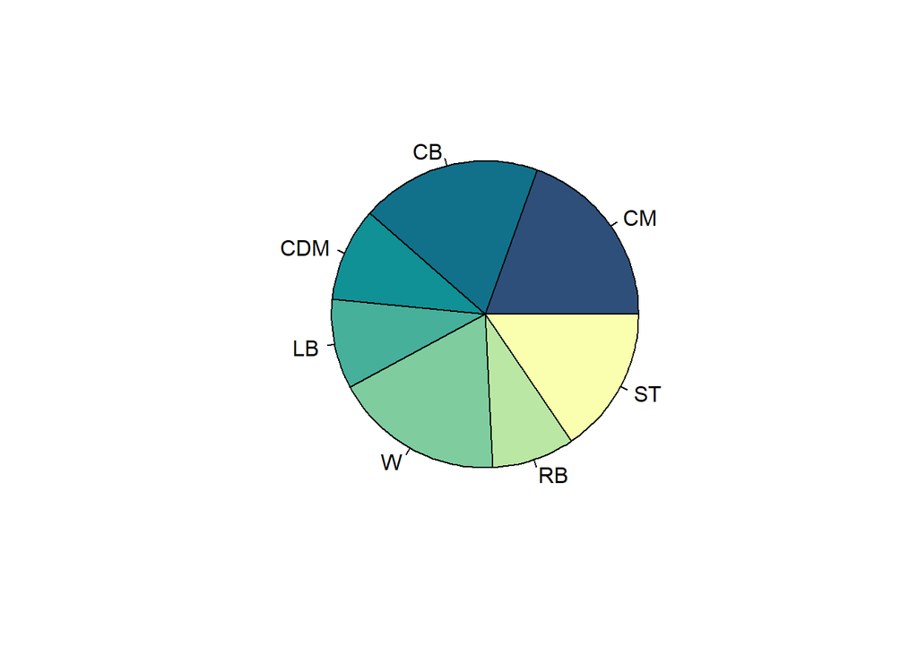

```r
#plot pie chart again
cat<- table(factor(test_y2))
pie(cat, col = hcl.colors(length(cat), "BluYl"))
```

This is the new distribution of labels. Now we reproduce the same experiments, expecting a hefty increase in accuracy, with the price of ablation.

### 3.7.1 Knn

```r
pred_knn2 <-knn(train = train, test = test, cl = train_y2, k = 51)
confusionMatrix(data=pred_knn2, reference = test_y2)
```

```
## Confusion Matrix and Statistics
##
##           Reference
## Prediction  CM  CB CDM  LB   W  RB  ST
##        CM  573   5 165  18 131  37  37
##        CB    2 654  47   8   0  19   7
##        CDM  47  35 150   1   3  14   2
##        LB   25  32  17 308  40   4  16
##        W   112   0   3  20 473  18  68
##        RB    5  21   7  20  16 247   3
##        ST    8   5   1   0  46   4 481
##
## Overall Statistics
##
##                Accuracy : 0.7297
##                  95% CI : (0.7156, 0.7435)
##     No Information Rate : 0.1952
##     P-Value [Acc > NIR] : < 2.2e-16
##
##                   Kappa : 0.6783
##
##  Mcnemar's Test P-Value : NA
##
## Statistics by Class:
##
##                      Class: CM Class: CB Class: CDM Class: LB Class: W
## Sensitivity             0.7422    0.8697    0.38462   0.82133   0.6671
## Specificity             0.8765    0.9741    0.97139   0.96257   0.9319
## Pos Pred Value          0.5932    0.8874    0.59524   0.69683   0.6816
## Neg Pred Value          0.9334    0.9695    0.93519   0.98093   0.9276
## Prevalence              0.1952    0.1901    0.09861   0.09482   0.1793
## Detection Rate          0.1449    0.1654    0.03793   0.07788   0.1196
## Detection Prevalence    0.2442    0.1863    0.06372   0.11176   0.1755
## Balanced Accuracy       0.8094    0.9219    0.67800   0.89195   0.7995
##                      Class: RB Class: ST
## Sensitivity            0.72012    0.7834
## Specificity            0.98007    0.9808
## Pos Pred Value         0.77429    0.8826
## Neg Pred Value         0.97360    0.9610
## Prevalence             0.08673    0.1552
## Detection Rate         0.06245    0.1216
## Detection Prevalence   0.08066    0.1378
## Balanced Accuracy      0.85009    0.8821
```

```r
accuracy(table(test_y2, pred_knn2))
```

```
## [1] 72.97092
```

### 3.7.2 Logistic Regression

```r
modellr2 <- nnet::multinom( train_y2~., data = train,trControl=crtl)
pred_lr2 <- predict(modellr2, test, type = "class")
accuracy(table(test_y2, pred_lr2))
```

```
## [1] 78.71049
```

```r
confusionMatrix(data=pred_lr2, reference = test_y2)
```

```
## Confusion Matrix and Statistics
##
##           Reference
## Prediction  CM  CB CDM  LB   W  RB  ST
##        CM  607   7 121  10  82   4  28
##        CB    3 671  47   8   0  16   2
##        CDM  60  22 203   1   5   4   0
##        LB    2  18   4 300  18   4   2
##        W    79   0   0  30 521  22  59
##        RB    4  29  15  26  24 292   4
##        ST   17   5   0   0  59   1 519
##
## Overall Statistics
##
##                Accuracy : 0.7871
##                  95% CI : (0.774, 0.7998)
##     No Information Rate : 0.1952
##     P-Value [Acc > NIR] : < 2.2e-16
##
##                   Kappa : 0.747
##
##  Mcnemar's Test P-Value : NA
##
## Statistics by Class:
##
##                      Class: CM Class: CB Class: CDM Class: LB Class: W
## Sensitivity             0.7863    0.8923    0.52051   0.80000   0.7348
## Specificity             0.9208    0.9763    0.97419   0.98659   0.9415
## Pos Pred Value          0.7066    0.8983    0.68814   0.86207   0.7328
## Neg Pred Value          0.9467    0.9748    0.94891   0.97921   0.9420
## Prevalence              0.1952    0.1901    0.09861   0.09482   0.1793
## Detection Rate          0.1535    0.1697    0.05133   0.07585   0.1317
## Detection Prevalence    0.2172    0.1889    0.07459   0.08799   0.1798
## Balanced Accuracy       0.8535    0.9343    0.74735   0.89330   0.8382
##                      Class: RB Class: ST
## Sensitivity            0.85131    0.8453
## Specificity            0.97176    0.9755
## Pos Pred Value         0.74112    0.8636
## Neg Pred Value         0.98568    0.9717
## Prevalence             0.08673    0.1552
## Detection Rate         0.07383    0.1312
## Detection Prevalence   0.09962    0.1520
## Balanced Accuracy      0.91154    0.9104
```

### 3.6.2 Random Forrest

```r
 model_rf2 <- randomForest(train_y2 ~ ., data = train, ntree = 500, mtry = 8, importance = TRUE)
pred_rf2 <- predict(model_rf2, test, type = "class")
summary(model_rf2)
```

```
##                 Length Class  Mode
## call                6  -none- call
## type                1  -none- character
## predicted        9228  factor numeric
## err.rate         4000  -none- numeric
## confusion          56  -none- numeric
## votes           64596  matrix numeric
## oob.times        9228  -none- numeric
## classes             7  -none- character
## importance        225  -none- numeric
## importanceSD      200  -none- numeric
## localImportance     0  -none- NULL
## proximity           0  -none- NULL
## ntree               1  -none- numeric
## mtry                1  -none- numeric
## forest             14  -none- list
## y                9228  factor numeric
## test                0  -none- NULL
## inbag               0  -none- NULL
## terms               3  terms  call
```

```r
accuracy(table(pred_rf2, test_y2))
```

```
## [1] 77.21871
```

```r
confusionMatrix(data=pred_rf2, reference = test_y2)
```

```
## Confusion Matrix and Statistics
##
##           Reference
## Prediction  CM  CB CDM  LB   W  RB  ST
##        CM  588   5 148  17  90  14  22
##        CB    2 690  56  14   0  21   4
##        CDM  61  22 173   1   2   7   0
##        LB    3  15   3 287  17   4   3
##        W    96   0   0  30 520  22  58
##        RB    4  16  10  26  22 270   1
##        ST   18   4   0   0  58   5 526
##
## Overall Statistics
##
##                Accuracy : 0.7722
##                  95% CI : (0.7588, 0.7852)
##     No Information Rate : 0.1952
##     P-Value [Acc > NIR] : < 2.2e-16
##
##                   Kappa : 0.7286
##
##  Mcnemar's Test P-Value : NA
##
## Statistics by Class:
##
##                      Class: CM Class: CB Class: CDM Class: LB Class: W
## Sensitivity             0.7617    0.9176    0.44359   0.76533   0.7334
## Specificity             0.9070    0.9697    0.97391   0.98743   0.9365
## Pos Pred Value          0.6652    0.8767    0.65038   0.86446   0.7163
## Neg Pred Value          0.9401    0.9804    0.94118   0.97571   0.9415
## Prevalence              0.1952    0.1901    0.09861   0.09482   0.1793
## Detection Rate          0.1487    0.1745    0.04374   0.07257   0.1315
## Detection Prevalence    0.2235    0.1990    0.06726   0.08394   0.1836
## Balanced Accuracy       0.8343    0.9436    0.70875   0.87638   0.8350
##                      Class: RB Class: ST
## Sensitivity            0.78717    0.8567
## Specificity            0.97813    0.9746
## Pos Pred Value         0.77364    0.8609
## Neg Pred Value         0.97976    0.9737
## Prevalence             0.08673    0.1552
## Detection Rate         0.06827    0.1330
## Detection Prevalence   0.08824    0.1545
## Balanced Accuracy      0.88265    0.9156
```

### 3.6.3 SVM

```r
model_svm2 <- svm(formula= train_y2~., data=train,
          type="C-classification", kernal="radial",
          gamma=0.1, cost=10)
pred_svm2 <- predict(model_svm2, test, type = "class")
```

```r
summary(model_svm2)
```

```
##
## Call:
## svm(formula = train_y2 ~ ., data = train, type = "C-classification",
##     kernal = "radial", gamma = 0.1, cost = 10)
##
##
## Parameters:
##    SVM-Type:  C-classification
##  SVM-Kernel:  radial
##        cost:  10
##
## Number of Support Vectors:  6424
##
##  ( 1325 866 567 1447 631 795 793 )
##
##
## Number of Classes:  7
##
## Levels:
##  CM CB CDM LB W RB ST
```

```r
accuracy(table(test_y2, pred_svm2))
```

```
## [1] 75.32238
```

```r
confusionMatrix(data=pred_svm2, reference = test_y2)
```

```
## Confusion Matrix and Statistics
##
##           Reference
## Prediction  CM  CB CDM  LB   W  RB  ST
##        CM  549   7 113   8  96   9  25
##        CB    5 676  44  12   0  23   1
##        CDM  59  25 202   0   3  11   2
##        LB    5  20   5 291  25  14   2
##        W   119   1   9  39 488  24  65
##        RB    9  20  13  23  23 259   5
##        ST   26   3   4   2  74   3 514
##
## Overall Statistics
##
##                Accuracy : 0.7532
##                  95% CI : (0.7395, 0.7666)
##     No Information Rate : 0.1952
##     P-Value [Acc > NIR] : < 2.2e-16
##
##                   Kappa : 0.7067
##
##  Mcnemar's Test P-Value : 0.001686
##
## Statistics by Class:
##
##                      Class: CM Class: CB Class: CDM Class: LB Class: W
## Sensitivity             0.7111    0.8989    0.51795   0.77600   0.6883
## Specificity             0.9189    0.9735    0.97195   0.98017   0.9208
## Pos Pred Value          0.6803    0.8883    0.66887   0.80387   0.6550
## Neg Pred Value          0.9292    0.9762    0.94854   0.97662   0.9312
## Prevalence              0.1952    0.1901    0.09861   0.09482   0.1793
## Detection Rate          0.1388    0.1709    0.05107   0.07358   0.1234
## Detection Prevalence    0.2040    0.1924    0.07636   0.09153   0.1884
## Balanced Accuracy       0.8150    0.9362    0.74495   0.87808   0.8046
##                      Class: RB Class: ST
## Sensitivity            0.75510    0.8371
## Specificity            0.97425    0.9665
## Pos Pred Value         0.73580    0.8211
## Neg Pred Value         0.97669    0.9700
## Prevalence             0.08673    0.1552
## Detection Rate         0.06549    0.1300
## Detection Prevalence   0.08900    0.1583
## Balanced Accuracy      0.86468    0.9018
```

Overall we can appreciate a significant improvement in accuracy, on average of 8-9%, in all the models. The model that performed the best was the Logistic Regression with 78.7%, followed in order by Random Forest (77.2%), SVM (75.3%) and KNN (72.9%). In today’s Machine Learning standards these might not seem staggering result, but we cannot neglect the challenging task we tried to address. In such a complex sport where roles and attributes intertwine and change during the season or even in the same match, classify with precision the position of a player is not an easy job, because often a player cannot be confined to a single area of the field.

## 4. Regularization: Ridge regression and Lasso

In this part we explore two shrinkage methods, namely Ridge regression and Lasso, also known as penalized regression methods. Through these techniques we can fit a model where all the predictors are contained, but some coefficient estimates are shrinked towards zero.

First we take the players_market and remove the player_positions column that we will not consider for this task.

```r
players_market <-subset(players_regress, select = -player_positions)
head(players_market)
```

|  | short_name | age | potential | international_reputation | value_eur | height_cm | weight_kg | pace | shooting | passing | preferred_foot | weak_foot | dribbling | defending | physic | attacking_crossing | attacking_finishing | attacking_heading_accuracy | attacking_short_passing | attacking_volleys | skill_dribbling | skill_curve | skill_fk_accuracy | skill_long_passing | skill_ball_control | movement_acceleration | movement_sprint_speed | movement_agility | movement_reactions | … |
| --- | --- | --- | --- | --- | --- | --- | --- | --- | --- | --- | --- | --- | --- | --- | --- | --- | --- | --- | --- | --- | --- | --- | --- | --- | --- | --- | --- | --- | --- | --- |
| 1 | L. Messi | 34 | 93 | 5 | 78000000 | 170 | 72 | 85 | 92 | 91 | Left | 4 | 95 | 34 | 65 | 85 | 95 | 70 | 91 | 88 | 96 | 93 | 94 | 91 | 96 | 91 | 80 | 91 | 94 | … |
| 2 | R. Lewandowski | 32 | 92 | 5 | 119500000 | 185 | 81 | 78 | 92 | 79 | Right | 4 | 86 | 44 | 82 | 71 | 95 | 90 | 85 | 89 | 85 | 79 | 85 | 70 | 88 | 77 | 79 | 77 | 93 | … |
| 3 | Cristiano Ronaldo | 36 | 91 | 5 | 45000000 | 187 | 83 | 87 | 94 | 80 | Right | 4 | 88 | 34 | 75 | 87 | 95 | 90 | 80 | 86 | 88 | 81 | 84 | 77 | 88 | 85 | 88 | 86 | 94 | … |
| 4 | Neymar Jr | 29 | 91 | 5 | 129000000 | 175 | 68 | 91 | 83 | 86 | Right | 5 | 94 | 37 | 63 | 85 | 83 | 63 | 86 | 86 | 95 | 88 | 87 | 81 | 95 | 93 | 89 | 96 | 89 | … |
| 5 | K. De Bruyne | 30 | 91 | 4 | 125500000 | 181 | 70 | 76 | 86 | 93 | Right | 5 | 88 | 64 | 78 | 94 | 82 | 55 | 94 | 82 | 88 | 85 | 83 | 93 | 91 | 76 | 76 | 79 | 91 | … |
| 7 | K. Mbappé | 22 | 95 | 4 | 194000000 | 182 | 73 | 97 | 88 | 80 | Right | 4 | 92 | 36 | 77 | 78 | 93 | 72 | 85 | 83 | 93 | 80 | 69 | 71 | 91 | 97 | 97 | 92 | 93 | … |

```r
players_market$value_eur <- as.integer(players_market$value_eur)
# Left foot is -1 and Right foot is 1. Basically one-hot encoding but we only have 2 categories so its easy
players_market$preferred_foot[players_market[,"preferred_foot"]== "Left"] <- as.numeric(-1)
players_market$preferred_foot[players_market[,"preferred_foot"]== "Right"] <- as.numeric(1)
players_market$preferred_foot <- as.numeric(players_market$preferred_foot)
head(players_market)
```

|  | short_name | age | potential | international_reputation | value_eur | height_cm | weight_kg | pace | shooting | passing | preferred_foot | weak_foot | dribbling | defending | physic | attacking_crossing | attacking_finishing | attacking_heading_accuracy | attacking_short_passing | attacking_volleys | skill_dribbling | skill_curve | skill_fk_accuracy | skill_long_passing | skill_ball_control | movement_acceleration | movement_sprint_speed | movement_agility | movement_reactions | … |
| --- | --- | --- | --- | --- | --- | --- | --- | --- | --- | --- | --- | --- | --- | --- | --- | --- | --- | --- | --- | --- | --- | --- | --- | --- | --- | --- | --- | --- | --- | --- |
| 1 | L. Messi | 34 | 93 | 5 | 78000000 | 170 | 72 | 85 | 92 | 91 | -1 | 4 | 95 | 34 | 65 | 85 | 95 | 70 | 91 | 88 | 96 | 93 | 94 | 91 | 96 | 91 | 80 | 91 | 94 | … |
| 2 | R. Lewandowski | 32 | 92 | 5 | 119500000 | 185 | 81 | 78 | 92 | 79 | 1 | 4 | 86 | 44 | 82 | 71 | 95 | 90 | 85 | 89 | 85 | 79 | 85 | 70 | 88 | 77 | 79 | 77 | 93 | … |
| 3 | Cristiano Ronaldo | 36 | 91 | 5 | 45000000 | 187 | 83 | 87 | 94 | 80 | 1 | 4 | 88 | 34 | 75 | 87 | 95 | 90 | 80 | 86 | 88 | 81 | 84 | 77 | 88 | 85 | 88 | 86 | 94 | … |
| 4 | Neymar Jr | 29 | 91 | 5 | 129000000 | 175 | 68 | 91 | 83 | 86 | 1 | 5 | 94 | 37 | 63 | 85 | 83 | 63 | 86 | 86 | 95 | 88 | 87 | 81 | 95 | 93 | 89 | 96 | 89 | … |
| 5 | K. De Bruyne | 30 | 91 | 4 | 125500000 | 181 | 70 | 76 | 86 | 93 | 1 | 5 | 88 | 64 | 78 | 94 | 82 | 55 | 94 | 82 | 88 | 85 | 83 | 93 | 91 | 76 | 76 | 79 | 91 | … |
| 7 | K. Mbappé | 22 | 95 | 4 | 194000000 | 182 | 73 | 97 | 88 | 80 | 1 | 4 | 92 | 36 | 77 | 78 | 93 | 72 | 85 | 83 | 93 | 80 | 69 | 71 | 91 | 97 | 97 | 92 | 93 | … |

```r
#norm
# normalization function
normalize <-function(x) { (x -min(x))/(max(x)-min(x))   }
colnames(players_market)
```

```
##  [1] "short_name"                  "age"
##  [3] "potential"                   "international_reputation"
##  [5] "value_eur"                   "height_cm"
##  [7] "weight_kg"                   "pace"
##  [9] "shooting"                    "passing"
## [11] "preferred_foot"              "weak_foot"
## [13] "dribbling"                   "defending"
## [15] "physic"                      "attacking_crossing"
## [17] "attacking_finishing"         "attacking_heading_accuracy"
## [19] "attacking_short_passing"     "attacking_volleys"
## [21] "skill_dribbling"             "skill_curve"
## [23] "skill_fk_accuracy"           "skill_long_passing"
## [25] "skill_ball_control"          "movement_acceleration"
## [27] "movement_sprint_speed"       "movement_agility"
## [29] "movement_reactions"          "movement_balance"
## [31] "power_shot_power"            "power_jumping"
## [33] "power_stamina"               "power_strength"
## [35] "power_long_shots"            "mentality_aggression"
## [37] "mentality_interceptions"     "mentality_positioning"
## [39] "mentality_vision"            "mentality_penalties"
## [41] "mentality_composure"         "defending_marking_awareness"
## [43] "defending_standing_tackle"   "defending_sliding_tackle"
```

```r
# normalize
players_market_norm <- as.data.frame(lapply(players_market[, c(2:44)], normalize))
head(players_market_norm,5)
```

|  | age | potential | international_reputation | value_eur | height_cm | weight_kg | pace | shooting | passing | preferred_foot | weak_foot | dribbling | defending | physic | attacking_crossing | attacking_finishing | attacking_heading_accuracy | attacking_short_passing | attacking_volleys | skill_dribbling | skill_curve | skill_fk_accuracy | skill_long_passing | skill_ball_control | movement_acceleration | movement_sprint_speed | movement_agility | movement_reactions | movement_balance | … |
| --- | --- | --- | --- | --- | --- | --- | --- | --- | --- | --- | --- | --- | --- | --- | --- | --- | --- | --- | --- | --- | --- | --- | --- | --- | --- | --- | --- | --- | --- | --- |
| 1 | 0.7826087 | 0.9565217 | 1.00 | 0.4020156 | 0.3125000 | 0.4423077 | 0.8260870 | 0.9736842 | 0.9705882 | 0 | 0.75 | 1.0000000 | 0.2500000 | 0.5901639 | 0.8860759 | 1.0000000 | 0.6973684 | 0.9577465 | 0.9750 | 1.0000000 | 0.9878049 | 1.0000000 | 0.9726027 | 1.0000000 | 0.9142857 | 0.7571429 | 0.9275362 | 1.0000000 | 0.9857143 | … |
| 2 | 0.6956522 | 0.9347826 | 1.00 | 0.6159497 | 0.6250000 | 0.6153846 | 0.7246377 | 0.9736842 | 0.7941176 | 1 | 0.75 | 0.8676471 | 0.3815789 | 0.8688525 | 0.7088608 | 1.0000000 | 0.9605263 | 0.8732394 | 0.9875 | 0.8589744 | 0.8170732 | 0.8928571 | 0.6849315 | 0.8888889 | 0.7142857 | 0.7428571 | 0.7246377 | 0.9846154 | 0.8000000 | … |
| 3 | 0.8695652 | 0.9130435 | 1.00 | 0.2318994 | 0.6666667 | 0.6538462 | 0.8550725 | 1.0000000 | 0.8088235 | 1 | 0.75 | 0.8970588 | 0.2500000 | 0.7540984 | 0.9113924 | 1.0000000 | 0.9605263 | 0.8028169 | 0.9500 | 0.8974359 | 0.8414634 | 0.8809524 | 0.7808219 | 0.8888889 | 0.8285714 | 0.8714286 | 0.8550725 | 1.0000000 | 0.6857143 | … |
| 4 | 0.5652174 | 0.9130435 | 1.00 | 0.6649225 | 0.4166667 | 0.3653846 | 0.9130435 | 0.8552632 | 0.8970588 | 1 | 1.00 | 0.9852941 | 0.2894737 | 0.5573770 | 0.8860759 | 0.8588235 | 0.6052632 | 0.8873239 | 0.9500 | 0.9871795 | 0.9268293 | 0.9166667 | 0.8356164 | 0.9861111 | 0.9428571 | 0.8857143 | 1.0000000 | 0.9230769 | 0.8285714 | … |
| 5 | 0.6086957 | 0.9130435 | 0.75 | 0.6468799 | 0.5416667 | 0.4038462 | 0.6956522 | 0.8947368 | 1.0000000 | 1 | 1.00 | 0.8970588 | 0.6447368 | 0.8032787 | 1.0000000 | 0.8470588 | 0.5000000 | 1.0000000 | 0.9000 | 0.8974359 | 0.8902439 | 0.8690476 | 1.0000000 | 0.9305556 | 0.7000000 | 0.7000000 | 0.7536232 | 0.9538462 | 0.7428571 | … |

```r
attach(players_market_norm)
X <- model.matrix(value_eur ~.,players_market_norm)
y <- value_eur
```

### 4.1 Ridge Regression

Ridge uses quadratic shrinking.

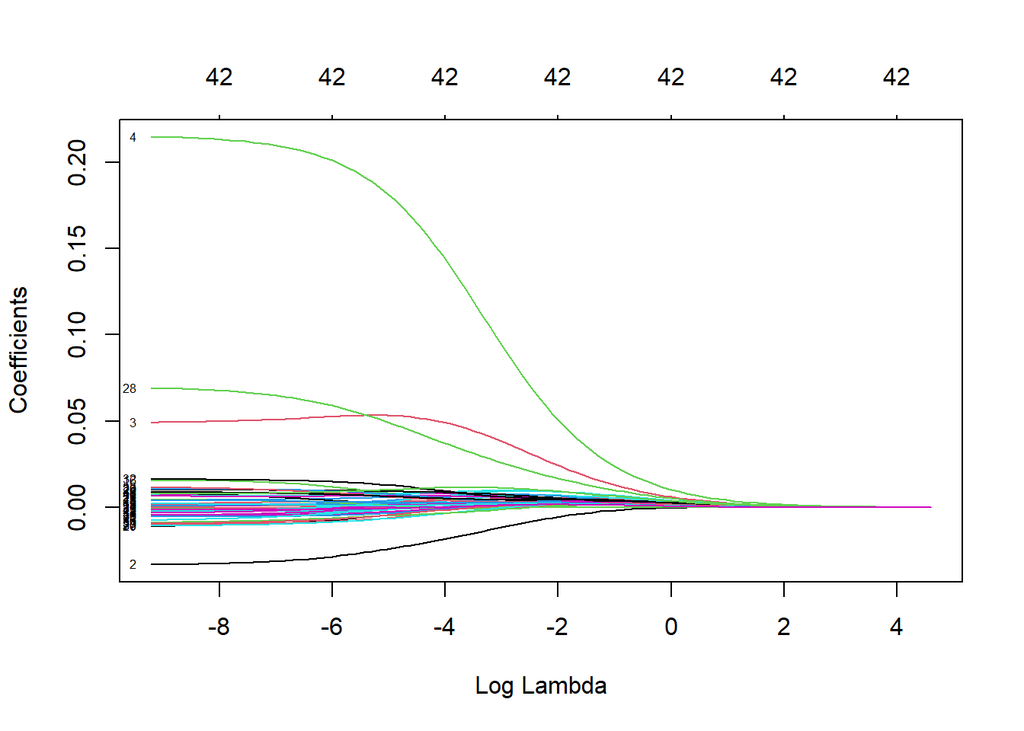

```r
#ridge regression
grid.ridge <-10^seq(-4,2,length=100)
ridge.mod<-glmnet(X,y,alpha = 0,lambda = grid.ridge)
plot(ridge.mod, xvar="lambda", label= TRUE)
```

The plot illustrates how much the coefficients are penalized for different values of lambda. Notice none of the coefficients are forced to be zero.

Looking at the plot the features:

```r
colnames(players_market)
```

```
##  [1] "short_name"                  "age"
##  [3] "potential"                   "international_reputation"
##  [5] "value_eur"                   "height_cm"
##  [7] "weight_kg"                   "pace"
##  [9] "shooting"                    "passing"
## [11] "preferred_foot"              "weak_foot"
## [13] "dribbling"                   "defending"
## [15] "physic"                      "attacking_crossing"
## [17] "attacking_finishing"         "attacking_heading_accuracy"
## [19] "attacking_short_passing"     "attacking_volleys"
## [21] "skill_dribbling"             "skill_curve"
## [23] "skill_fk_accuracy"           "skill_long_passing"
## [25] "skill_ball_control"          "movement_acceleration"
## [27] "movement_sprint_speed"       "movement_agility"
## [29] "movement_reactions"          "movement_balance"
## [31] "power_shot_power"            "power_jumping"
## [33] "power_stamina"               "power_strength"
## [35] "power_long_shots"            "mentality_aggression"
## [37] "mentality_interceptions"     "mentality_positioning"
## [39] "mentality_vision"            "mentality_penalties"
## [41] "mentality_composure"         "defending_marking_awareness"
## [43] "defending_standing_tackle"   "defending_sliding_tackle"
```

```r
# select n/2 observations for training set
train <- sample(1:nrow(X), nrow(X)/2)
test <- (-train)
y.test <- y[test]
```

```r
# fit ridge regression on the training set
ridge.mod <- glmnet(X[train, ], y[train], alpha = 0,
                    lambda = grid.ridge, thresh = 1e-12)
```

We estimate the test MSE for one lambda value, e.g lambda = 9

```r
#We estimate the test MSE for one lambda value, e.g lambda = 9
ridge.pred <- predict(ridge.mod, s = 9, newx = X[test, ], type="response")
mean((ridge.pred - y.test)^2)
```

```
## [1] 0.002040698
```

let’s see the coefficients for lambda = 9

```r
predict(ridge.mod, s = 9, exact = TRUE, type = "coefficients",
        x = X[train, ], y = y[train])[1:41, ]
```

```
##                (Intercept)                (Intercept)
##               1.088777e-02               0.000000e+00
##                        age                  potential
##               3.844676e-05               8.079290e-04
##   international_reputation                  height_cm
##               1.268657e-03               8.481373e-05
##                  weight_kg                       pace
##               1.225221e-04               2.533876e-04
##                   shooting                    passing
##               3.305241e-04               5.376185e-04
##             preferred_foot                  weak_foot
##              -4.531360e-06               1.912625e-04
##                  dribbling                  defending
##               5.675027e-04               1.393295e-04
##                     physic         attacking_crossing
##               2.993649e-04               3.346249e-04
##        attacking_finishing attacking_heading_accuracy
##               2.824697e-04               3.197270e-04
##    attacking_short_passing          attacking_volleys
##               6.535299e-04               3.271983e-04
##            skill_dribbling                skill_curve
##               4.654953e-04               3.372552e-04
##          skill_fk_accuracy         skill_long_passing
##               2.843348e-04               3.959557e-04
##         skill_ball_control      movement_acceleration
##               6.532623e-04               2.302409e-04
##      movement_sprint_speed           movement_agility
##               2.486640e-04               2.238252e-04
##         movement_reactions           movement_balance
##               7.552708e-04               1.434842e-04
##           power_shot_power              power_jumping
##               3.627821e-04               1.447466e-04
##              power_stamina             power_strength
##               3.418250e-04               1.794867e-04
##           power_long_shots       mentality_aggression
##               2.972412e-04               2.392645e-04
##    mentality_interceptions      mentality_positioning
##               1.208521e-04               3.498357e-04
##           mentality_vision        mentality_penalties
##               4.497341e-04               2.975080e-04
##        mentality_composure
##               5.715892e-04
```

We use cross-validation to choose the value of lambda

```r
cv.out.ridge <- cv.glmnet(X[train, ], y[train], alpha = 0, nfold=10)
cv.out.ridge$lambda[1:10]
```

```
##  [1] 27.61409 25.16093 22.92570 20.88905 19.03332 17.34245 15.80180 14.39801
##  [9] 13.11893 11.95348
```

```r
summary(cv.out.ridge$lambda)
```

```
##      Min.   1st Qu.    Median      Mean   3rd Qu.      Max.
##  0.002761  0.027636  0.276440  3.108108  2.763685 27.614090
```

```r
# The mean cross-validated error
cv.out.ridge$cvm[1:10]
```

```
##  [1] 0.001894262 0.001874377 0.001869855 0.001867391 0.001864706 0.001861782
##  [7] 0.001858602 0.001855144 0.001851388 0.001847312
```

The following plot shows the cross-validation curve (red dotted line) with upper and lower standard deviation curves along the lambda sequence (error bars).

Two special values along the lambda sequence are indicated by the vertical dotted lines:

lambda.min is the value of lambda that gives minimum mean cross-validated error, while lambda.1se is the value of lambda that gives the most regularized model such that the cross-validated error is within one standard error of the minimum.

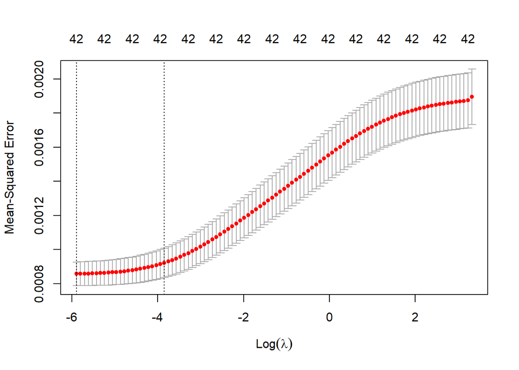

```r
plot(cv.out.ridge)
```

```r
# identify the best lambda value
i.bestlam <- which.min(cv.out.ridge$cvm)
i.bestlam
```

```
## [1] 100
```

```r
bestlam <- cv.out.ridge$lambda[i.bestlam]
bestlam
```

```
## [1] 0.002761409
```

```r
# mean cross-validated error for best lambda
cv.out.ridge$cvm[i.bestlam]
```

```
## [1] 0.0008573019
```

```r
# estimate the test MSE
ridge.pred <- predict(ridge.mod, s = bestlam,
                      newx = X[test, ])
#MSE
mean((ridge.pred - y.test)^2)
```

```
## [1] 0.0009352046
```

```r
# fit the coefficient with lambda=bestlam on all the data
out <- glmnet(X, y, alpha = 0)
predict(out, type = "coefficients", s = bestlam)
```

```
## 44 x 1 sparse Matrix of class "dgCMatrix"
##                                        s1
## (Intercept)                 -0.0723140503
## (Intercept)                  .
## age                         -0.0277912710
## potential                    0.0528695501
## international_reputation     0.1987834173
## height_cm                    0.0052479420
## weight_kg                   -0.0023766865
## pace                         0.0081741359
## shooting                     0.0037478398
## passing                      0.0032878494
## preferred_foot              -0.0003350786
## weak_foot                    0.0019683724
## dribbling                   -0.0012836592
## defending                    0.0009078396
## physic                       0.0077565378
## attacking_crossing           0.0003103480
## attacking_finishing          0.0115587699
## attacking_heading_accuracy   0.0026543530
## attacking_short_passing      0.0071171730
## attacking_volleys           -0.0015097796
## skill_dribbling             -0.0069628036
## skill_curve                 -0.0004080408
## skill_fk_accuracy            0.0026058103
## skill_long_passing          -0.0012107416
## skill_ball_control           0.0008634378
## movement_acceleration        0.0065536710
## movement_sprint_speed        0.0097110603
## movement_agility            -0.0078658353
## movement_reactions           0.0577623407
## movement_balance             0.0093242251
## power_shot_power            -0.0081411233
## power_jumping               -0.0035208811
## power_stamina                0.0147824128
## power_strength               0.0083613424
## power_long_shots            -0.0059305628
## mentality_aggression        -0.0043741063
## mentality_interceptions     -0.0030247251
## mentality_positioning       -0.0002608931
## mentality_vision             0.0073916237
## mentality_penalties         -0.0064979429
## mentality_composure          0.0092059060
## defending_marking_awareness  0.0031617404
## defending_standing_tackle    0.0011006923
## defending_sliding_tackle    -0.0009163138
```

```r
# residual sum of squares
ridge.rss <- sum((ridge.pred - y.test)^2)
ridge.rss
```

```
## [1] 6.164869
```

Let’s compute the R squared. The R squared is a statistical measure of how well the regression predictions approximate the real data points. An R2 of 1 indicates that the regression predictions perfectly fit the data

```r
ridge.tss <- sum((y.test - mean(y.test)) ^ 2)  ## total sum of squares
ridge.rsq <- 1 - ridge.rss/ridge.tss  # R squared
ridge.rsq
```

```
## [1] 0.5564568
```

### 4.2 Lasso Regularization

Lasso uses absolute-value shrinking.

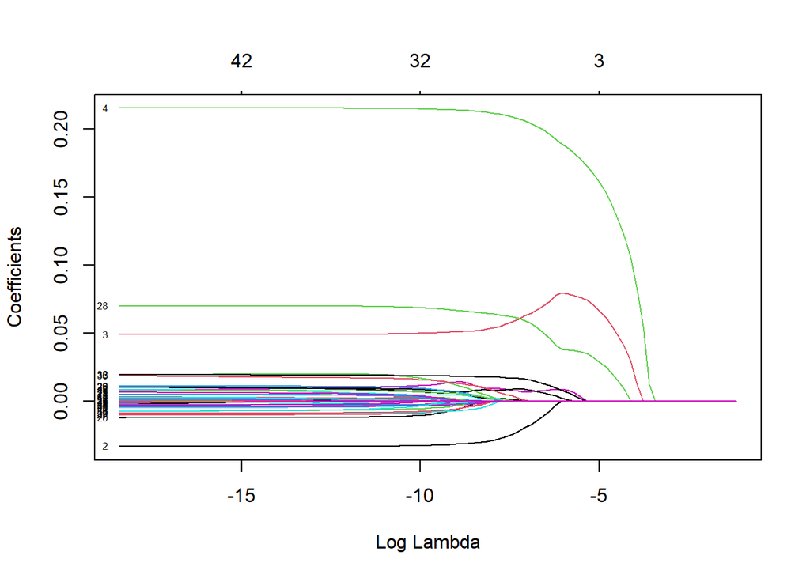

```r
grid.lasso<-10^seq(-0.5,-8,length=100)
lasso.mod<-glmnet(X,y,alpha = 1,lambda = grid.lasso)
plot(lasso.mod, xvar="lambda", label = TRUE)
```

We use cross-validation to choose the value of lambda

```r
cv.out.lasso <- cv.glmnet(X[train, ], y[train], alpha = 1, nfold=10)
cv.out.lasso$lambda[1:10]
```

```
##  [1] 0.02761409 0.02516093 0.02292570 0.02088905 0.01903332 0.01734245
##  [7] 0.01580180 0.01439801 0.01311893 0.01195348
```

```r
# apply lasso to the training set
lasso.mod <- glmnet(X[train,], y[train], alpha=1, lambda=grid.lasso)
```

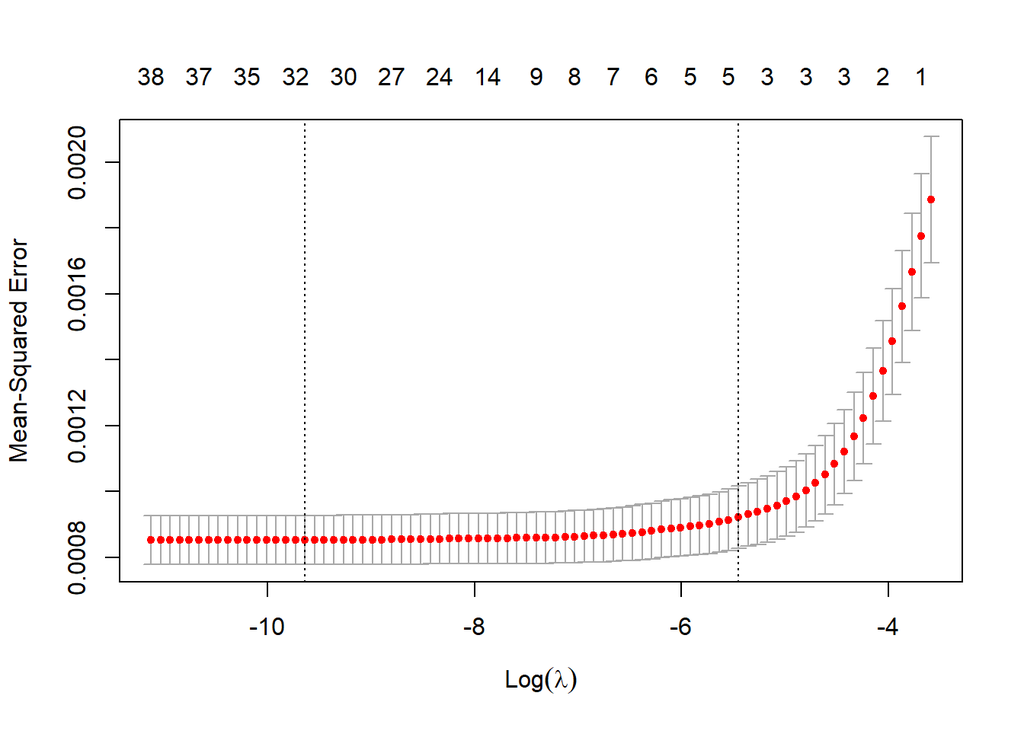

```r
# apply 10fold cross-validation to the training set
cv.out.lasso <- cv.glmnet(X[train,], y[train], alpha=1)
plot(cv.out.lasso)
```

```r
# estimate test MSE
bestlam <- cv.out.lasso$lambda.min
lasso.pred <- predict(lasso.mod, s=bestlam, newx=X[test,])
mean((lasso.pred-y.test)^2)
```

```
## [1] 0.0009281257
```

```r
# fit the model with best-lambda on all the data
lasso.coef <- predict(lasso.mod,type="coefficients",s=bestlam)[1:44,]
lasso.coef
```

```
##                 (Intercept)                 (Intercept)
##               -0.0700086157                0.0000000000
##                         age                   potential
##               -0.0327822931                0.0478762929
##    international_reputation                   height_cm
##                0.2076411021                0.0046156413
##                   weight_kg                        pace
##                0.0006093772                0.0030624471
##                    shooting                     passing
##                0.0000000000                0.0000000000
##              preferred_foot                   weak_foot
##               -0.0010156365                0.0000000000
##                   dribbling                   defending
##                0.0000000000                0.0000000000
##                      physic          attacking_crossing
##                0.0000000000                0.0009885228
##         attacking_finishing  attacking_heading_accuracy
##                0.0174554515                0.0055992081
##     attacking_short_passing           attacking_volleys
##                0.0076089278               -0.0010496705
##             skill_dribbling                 skill_curve
##               -0.0092430676               -0.0035565897
##           skill_fk_accuracy          skill_long_passing
##                0.0092326280               -0.0024819947
##          skill_ball_control       movement_acceleration
##                0.0000000000                0.0038861309
##       movement_sprint_speed            movement_agility
##                0.0171929792               -0.0083969806
##          movement_reactions            movement_balance
##                0.0655784093                0.0094006466
##            power_shot_power               power_jumping
##               -0.0051379458               -0.0039456886
##               power_stamina              power_strength
##                0.0199717551                0.0123359522
##            power_long_shots        mentality_aggression
##               -0.0074238244               -0.0005190495
##     mentality_interceptions       mentality_positioning
##               -0.0036212838               -0.0004165908
##            mentality_vision         mentality_penalties
##                0.0099833188               -0.0131316470
##         mentality_composure defending_marking_awareness
##                0.0046010020                0.0000000000
##   defending_standing_tackle    defending_sliding_tackle
##                0.0000000000                0.0000000000
```

We check which coefficients were forced to zero

```r
lasso.coef[lasso.coef!=0]
```

```
##                (Intercept)                        age
##              -0.0700086157              -0.0327822931
##                  potential   international_reputation
##               0.0478762929               0.2076411021
##                  height_cm                  weight_kg
##               0.0046156413               0.0006093772
##                       pace             preferred_foot
##               0.0030624471              -0.0010156365
##         attacking_crossing        attacking_finishing
##               0.0009885228               0.0174554515
## attacking_heading_accuracy    attacking_short_passing
##               0.0055992081               0.0076089278
##          attacking_volleys            skill_dribbling
##              -0.0010496705              -0.0092430676
##                skill_curve          skill_fk_accuracy
##              -0.0035565897               0.0092326280
##         skill_long_passing      movement_acceleration
##              -0.0024819947               0.0038861309
##      movement_sprint_speed           movement_agility
##               0.0171929792              -0.0083969806
##         movement_reactions           movement_balance
##               0.0655784093               0.0094006466
##           power_shot_power              power_jumping
##              -0.0051379458              -0.0039456886
##              power_stamina             power_strength
##               0.0199717551               0.0123359522
##           power_long_shots       mentality_aggression
##              -0.0074238244              -0.0005190495
##    mentality_interceptions      mentality_positioning
##              -0.0036212838              -0.0004165908
##           mentality_vision        mentality_penalties
##               0.0099833188              -0.0131316470
##        mentality_composure
##               0.0046010020
```

```r
length(lasso.coef[lasso.coef!=0])
```

```
## [1] 33
```

```r
which(lasso.coef==0)
```

```
##                 (Intercept)                    shooting
##                           2                           9
##                     passing                   weak_foot
##                          10                          12
##                   dribbling                   defending
##                          13                          14
##                      physic          skill_ball_control
##                          15                          25
## defending_marking_awareness   defending_standing_tackle
##                          42                          43
##    defending_sliding_tackle
##                          44
```

```r
# residual sum of squares
lasso.rss <- sum((lasso.pred - y.test)^2)
lasso.rss
```

```
## [1] 6.118205
```

```r
lasso.tss <- sum((y.test - mean(y.test)) ^ 2)  ## total sum of squares
lasso.rsq <- 1 - lasso.rss/lasso.tss  # R squared
lasso.rsq
```

```
## [1] 0.5598142
```

```r
#ridge.rss vs lasso.rss
ridge.rss
```

```
## [1] 6.164869
```

```r
lasso.rss
```

```
## [1] 6.118205
```

```r
#ridge.rsq vs lasso.rsq
ridge.rsq
```

```
## [1] 0.5564568
```

```r
lasso.rsq
```

```
## [1] 0.5598142
```

### 5. Conclusion and further research

All in all, position classification is possible for some distinct areas of the football field, but for some specific ones is quite impossible, in the case of multiclass classification.

On one hand, football is a very heterogeneous sport and often the values of the attributes cannot explain as a whole the position of a player since his style of play heavily influence how the role is interpreted and consequently where exactly the player acts on the field. On the other hand, we would also like to believe that with sufficient data, even effective positioning of real players could be calculated.